# SeqMonk Vistory Report

[figure not shown]

## Identification of DMRs in Tet2 KO vs WT LSK, CMP and GMP populations

Project Loaded

Loaded /Users/r.strogantsev/OneDrive - Oregon Health & Science University/TET2-IL1b_sequencing_data/M&T_LibraryPrep_sortedBulkPops/BS-PBAT/Seqmonk_analysis/All_combined/LKS-GMP-CMP_WGBS.smk

DataSet Added

KO_stm_rep1 (403 CMP R1) /Users/strogant/Box/TET2-IL1b_sequencing_data/M&T_LibraryPrep_sortedBulkPops/BS-PBAT2/CpGcov/LIB210401AA_403_CMP_S22_L001_R1_001_val_1_bismark_bt2.multiple.deduplicated.bismark.cov.gz Cov Parser - No Options

DataSet Added

KO_stm_rep1 (403 CMP R2) /Users/strogant/Box/TET2-IL1b_sequencing_data/M&T_LibraryPrep_sortedBulkPops/BS-PBAT2/CpGcov/LIB210401AA_403_CMP_S22_L001_R2_001_val_2_bismark_bt2.multiple.deduplicated.bismark.cov.gz Cov Parser - No Options

DataSet Added

KO_stm_rep1 (403 CMP) /Users/strogant/Box/TET2-IL1b_sequencing_data/M&T_LibraryPrep_sortedBulkPops/BS-PBAT2/CpGcov/LIB201023AA_realigned/LIB201023AA_403_CMP_S30_R1_001_trimmed_bismark_bt2.deduplicated.bismark.cov.gz Cov Parser - No Options

DataSet Added

KO_stm_rep1 (403 GMP R1) /Users/strogant/Box/TET2-IL1b_sequencing_data/M&T_LibraryPrep_sortedBulkPops/BS-PBAT2/CpGcov/LIB210401AA_403_GMP_S23_L001_R1_001_val_1_bismark_bt2.multiple.deduplicated.bismark.cov.gz Cov Parser - No Options

DataSet Added

KO_stm_rep1 (403 GMP R2) /Users/strogant/Box/TET2-IL1b_sequencing_data/M&T_LibraryPrep_sortedBulkPops/BS-PBAT2/CpGcov/LIB210401AA_403_GMP_S23_L001_R2_001_val_2_bismark_bt2.multiple.deduplicated.bismark.cov.gz Cov Parser - No Options

DataSet Added

KO_stm_rep1 (403 GMP) /Users/strogant/Box/TET2-IL1b_sequencing_data/M&T_LibraryPrep_sortedBulkPops/BS-PBAT2/CpGcov/LIB201023AA_realigned/LIB201023AA_403_GMP_S31_R1_001_trimmed_bismark_bt2.deduplicated.bismark.cov.gz Cov Parser - No Options

DataSet Added

KO_stm_rep2 (404 CMP R1) /Users/strogant/Box/TET2-IL1b_sequencing_data/M&T_LibraryPrep_sortedBulkPops/BS-PBAT2/CpGcov/LIB210401AA_404_CMP_S46_L001_R1_001_val_1_bismark_bt2.multiple.deduplicated.bismark.cov.gz Cov Parser - No Options

DataSet Added

KO_stm_rep2 (404 CMP R2) /Users/strogant/Box/TET2-IL1b_sequencing_data/M&T_LibraryPrep_sortedBulkPops/BS-PBAT2/CpGcov/LIB210401AA_404_CMP_S46_L001_R2_001_val_2_bismark_bt2.multiple.deduplicated.bismark.cov.gz Cov Parser - No Options

DataSet Added

KO_stm_rep2 (404 CMP) /Users/strogant/Box/TET2-IL1b_sequencing_data/M&T_LibraryPrep_sortedBulkPops/BS-PBAT2/CpGcov/LIB201023AA_realigned/LIB201023AA_404_CMP_S62_R1_001_trimmed_bismark_bt2.deduplicated.bismark.cov.gz Cov Parser - No Options

DataSet Added

KO_stm_rep2 (404 GMP R1) /Users/strogant/Box/TET2-IL1b_sequencing_data/M&T_LibraryPrep_sortedBulkPops/BS-PBAT2/CpGcov/LIB210401AA_404_GMP_S6_L001_R1_001_val_1_bismark_bt2.multiple.deduplicated.bismark.cov.gz Cov Parser - No Options

DataSet Added

KO_stm_rep2 (404 GMP R2) /Users/strogant/Box/TET2-IL1b_sequencing_data/M&T_LibraryPrep_sortedBulkPops/BS-PBAT2/CpGcov/LIB210401AA_404_GMP_S6_L001_R2_001_val_2_bismark_bt2.multiple.deduplicated.bismark.cov.gz Cov Parser - No Options

DataSet Added

KO_stm_rep2 (404 GMP) /Users/strogant/Box/TET2-IL1b_sequencing_data/M&T_LibraryPrep_sortedBulkPops/BS-PBAT2/CpGcov/LIB201023AA_realigned/LIB201023AA_404_GMP_S8_R1_001_trimmed_bismark_bt2.deduplicated.bismark.cov.gz Cov Parser - No Options

DataSet Added

KO_stm_rep3 (657 CMP R1) /Users/strogant/Box/TET2-IL1b_sequencing_data/M&T_LibraryPrep_sortedBulkPops/BS-PBAT2/CpGcov/LIB210401AA_657_CMP_S20_L001_R1_001_val_1_bismark_bt2.multiple.deduplicated.bismark.cov.gz Cov Parser - No Options

DataSet Added

KO_stm_rep3 (657 CMP R2) /Users/strogant/Box/TET2-IL1b_sequencing_data/M&T_LibraryPrep_sortedBulkPops/BS-PBAT2/CpGcov/LIB210401AA_657_CMP_S20_L001_R2_001_val_2_bismark_bt2.multiple.deduplicated.bismark.cov.gz Cov Parser - No Options

DataSet Added

KO_stm_rep3 (657 CMP) /Users/strogant/Box/TET2-IL1b_sequencing_data/M&T_LibraryPrep_sortedBulkPops/BS-PBAT2/CpGcov/LIB201023AA_realigned/LIB201023AA_657_CMP_S28_R1_001_trimmed_bismark_bt2.deduplicated.bismark.cov.gz Cov Parser - No Options

DataSet Added

KO_stm_rep3 (657 GMP R1) /Users/strogant/Box/TET2-IL1b_sequencing_data/M&T_LibraryPrep_sortedBulkPops/BS-PBAT2/CpGcov/LIB210401AA_657_GMP_S12_L001_R1_001_val_1_bismark_bt2.multiple.deduplicated.bismark.cov.gz Cov Parser - No Options

DataSet Added

KO_stm_rep3 (657 GMP R2) /Users/strogant/Box/TET2-IL1b_sequencing_data/M&T_LibraryPrep_sortedBulkPops/BS-PBAT2/CpGcov/LIB210401AA_657_GMP_S12_L001_R2_001_val_2_bismark_bt2.multiple.deduplicated.bismark.cov.gz Cov Parser - No Options

DataSet Added

KO_stm_rep3 (657 GMP) /Users/strogant/Box/TET2-IL1b_sequencing_data/M&T_LibraryPrep_sortedBulkPops/BS-PBAT2/CpGcov/LIB201023AA_realigned/LIB201023AA_657_GMP_S18_R1_001_trimmed_bismark_bt2.deduplicated.bismark.cov.gz Cov Parser - No Options

DataSet Added

KO_stm_rep4 (419 CMP R1) /Users/strogant/Box/TET2-IL1b_sequencing_data/M&T_LibraryPrep_sortedBulkPops/BS-PBAT2/CpGcov/LIB210401AA_419_CMP_S40_L001_R1_001_val_1_bismark_bt2.multiple.deduplicated.bismark.cov.gz Cov Parser - No Options

DataSet Added

KO_stm_rep4 (419 CMP R2) /Users/strogant/Box/TET2-IL1b_sequencing_data/M&T_LibraryPrep_sortedBulkPops/BS-PBAT2/CpGcov/LIB210401AA_419_CMP_S40_L001_R2_001_val_2_bismark_bt2.multiple.deduplicated.bismark.cov.gz Cov Parser - No Options

DataSet Added

KO_stm_rep4 (419 CMP) /Users/strogant/Box/TET2-IL1b_sequencing_data/M&T_LibraryPrep_sortedBulkPops/BS-PBAT2/CpGcov/LIB201023AA_realigned/LIB201023AA_419_CMP_S54_R1_001_trimmed_bismark_bt2.deduplicated.bismark.cov.gz Cov Parser - No Options

DataSet Added

KO_stm_rep4 (419 GMP R1) /Users/strogant/Box/TET2-IL1b_sequencing_data/M&T_LibraryPrep_sortedBulkPops/BS-PBAT2/CpGcov/LIB210401AA_419_GMP_S24_L001_R1_001_val_1_bismark_bt2.multiple.deduplicated.bismark.cov.gz Cov Parser - No Options

DataSet Added

KO_stm_rep4 (419 GMP R2) /Users/strogant/Box/TET2-IL1b_sequencing_data/M&T_LibraryPrep_sortedBulkPops/BS-PBAT2/CpGcov/LIB210401AA_419_GMP_S24_L001_R2_001_val_2_bismark_bt2.multiple.deduplicated.bismark.cov.gz Cov Parser - No Options

DataSet Added

KO_stm_rep4 (419 GMP) /Users/strogant/Box/TET2-IL1b_sequencing_data/M&T_LibraryPrep_sortedBulkPops/BS-PBAT2/CpGcov/LIB201023AA_realigned/LIB201023AA_419_GMP_S34_R1_001_trimmed_bismark_bt2.deduplicated.bismark.cov.gz Cov Parser - No Options

DataSet Added

KO_unt_rep1 (659 CMP R1) /Users/strogant/Box/TET2-IL1b_sequencing_data/M&T_LibraryPrep_sortedBulkPops/BS-PBAT2/CpGcov/LIB210401AA_659_CMP_S10_L001_R1_001_val_1_bismark_bt2.multiple.deduplicated.bismark.cov.gz Cov Parser - No Options

DataSet Added

KO_unt_rep1 (659 CMP R2) /Users/strogant/Box/TET2-IL1b_sequencing_data/M&T_LibraryPrep_sortedBulkPops/BS-PBAT2/CpGcov/LIB210401AA_659_CMP_S10_L001_R2_001_val_2_bismark_bt2.multiple.deduplicated.bismark.cov.gz Cov Parser - No Options

DataSet Added

KO_unt_rep1 (659 CMP) /Users/strogant/Box/TET2-IL1b_sequencing_data/M&T_LibraryPrep_sortedBulkPops/BS-PBAT/CpGcov/659_CMP_S14_R1.cov.gz Cov Parser - No Options

DataSet Added

KO_unt_rep1 (659 GMP R1) /Users/strogant/Box/TET2-IL1b_sequencing_data/M&T_LibraryPrep_sortedBulkPops/BS-PBAT2/CpGcov/LIB210401AA_659_GMP_S16_L001_R1_001_val_1_bismark_bt2.multiple.deduplicated.bismark.cov.gz Cov Parser - No Options

DataSet Added

KO_unt_rep1 (659 GMP R2) /Users/strogant/Box/TET2-IL1b_sequencing_data/M&T_LibraryPrep_sortedBulkPops/BS-PBAT2/CpGcov/LIB210401AA_659_GMP_S16_L001_R2_001_val_2_bismark_bt2.multiple.deduplicated.bismark.cov.gz Cov Parser - No Options

DataSet Added

KO_unt_rep1 (659 GMP) /Users/strogant/Box/TET2-IL1b_sequencing_data/M&T_LibraryPrep_sortedBulkPops/BS-PBAT2/CpGcov/LIB201023AA_realigned/LIB201023AA_659_GMP_S22_R1_001_trimmed_bismark_bt2.deduplicated.bismark.cov.gz Cov Parser - No Options

DataSet Added

KO_unt_rep2 (658 CMP R1) /Users/strogant/Box/TET2-IL1b_sequencing_data/M&T_LibraryPrep_sortedBulkPops/BS-PBAT2/CpGcov/LIB210401AA_658_CMP_S42_L001_R1_001_val_1_bismark_bt2.multiple.deduplicated.bismark.cov.gz Cov Parser - No Options

DataSet Added

KO_unt_rep2 (658 CMP R2) /Users/strogant/Box/TET2-IL1b_sequencing_data/M&T_LibraryPrep_sortedBulkPops/BS-PBAT2/CpGcov/LIB210401AA_658_CMP_S42_L001_R2_001_val_2_bismark_bt2.multiple.deduplicated.bismark.cov.gz Cov Parser - No Options

DataSet Added

KO_unt_rep2 (658 CMP) /Users/strogant/Box/TET2-IL1b_sequencing_data/M&T_LibraryPrep_sortedBulkPops/BS-PBAT2/CpGcov/LIB201023AA_realigned/LIB201023AA_658_CMP_S56_R1_001_trimmed_bismark_bt2.deduplicated.bismark.cov.gz Cov Parser - No Options

DataSet Added

KO_unt_rep2 (658 GMP R1) /Users/strogant/Box/TET2-IL1b_sequencing_data/M&T_LibraryPrep_sortedBulkPops/BS-PBAT2/CpGcov/LIB210401AA_658_GMP_S43_L001_R1_001_val_1_bismark_bt2.multiple.deduplicated.bismark.cov.gz Cov Parser - No Options

DataSet Added

KO_unt_rep2 (658 GMP R2) /Users/strogant/Box/TET2-IL1b_sequencing_data/M&T_LibraryPrep_sortedBulkPops/BS-PBAT2/CpGcov/LIB210401AA_658_GMP_S43_L001_R2_001_val_2_bismark_bt2.multiple.deduplicated.bismark.cov.gz Cov Parser - No Options

DataSet Added

KO_unt_rep2 (658 GMP) /Users/strogant/Box/TET2-IL1b_sequencing_data/M&T_LibraryPrep_sortedBulkPops/BS-PBAT2/CpGcov/LIB201023AA_realigned/LIB201023AA_658_GMP_S57_R1_001_trimmed_bismark_bt2.deduplicated.bismark.cov.gz Cov Parser - No Options

DataSet Added

KO_unt_rep3 (405 CMP R1) /Users/strogant/Box/TET2-IL1b_sequencing_data/M&T_LibraryPrep_sortedBulkPops/BS-PBAT2/CpGcov/LIB210401AA_405_CMP_S32_L001_R1_001_val_1_bismark_bt2.multiple.deduplicated.bismark.cov.gz Cov Parser - No Options

DataSet Added

KO_unt_rep3 (405 CMP R2) /Users/strogant/Box/TET2-IL1b_sequencing_data/M&T_LibraryPrep_sortedBulkPops/BS-PBAT2/CpGcov/LIB210401AA_405_CMP_S32_L001_R2_001_val_2_bismark_bt2.multiple.deduplicated.bismark.cov.gz Cov Parser - No Options

DataSet Added

KO_unt_rep3 (405 CMP) /Users/strogant/Box/TET2-IL1b_sequencing_data/M&T_LibraryPrep_sortedBulkPops/BS-PBAT2/CpGcov/LIB201023AA_realigned/LIB201023AA_405_CMP_S44_R1_001_trimmed_bismark_bt2.deduplicated.bismark.cov.gz Cov Parser - No Options

DataSet Added

KO_unt_rep3 (405 GMP R1) /Users/strogant/Box/TET2-IL1b_sequencing_data/M&T_LibraryPrep_sortedBulkPops/BS-PBAT2/CpGcov/LIB210401AA_405_GMP_S17_L001_R1_001_val_1_bismark_bt2.multiple.deduplicated.bismark.cov.gz Cov Parser - No Options

DataSet Added

KO_unt_rep3 (405 GMP R2) /Users/strogant/Box/TET2-IL1b_sequencing_data/M&T_LibraryPrep_sortedBulkPops/BS-PBAT2/CpGcov/LIB210401AA_405_GMP_S17_L001_R2_001_val_2_bismark_bt2.multiple.deduplicated.bismark.cov.gz Cov Parser - No Options

DataSet Added

KO_unt_rep3 (405 GMP) /Users/strogant/Box/TET2-IL1b_sequencing_data/M&T_LibraryPrep_sortedBulkPops/BS-PBAT2/CpGcov/LIB201023AA_realigned/LIB201023AA_405_GMP_S23_R1_001_trimmed_bismark_bt2.deduplicated.bismark.cov.gz Cov Parser - No Options

DataSet Added

KO_unt_rep4 (406 CMP R1) /Users/strogant/Box/TET2-IL1b_sequencing_data/M&T_LibraryPrep_sortedBulkPops/BS-PBAT2/CpGcov/LIB210401AA_406_CMP_S44_L001_R1_001_val_1_bismark_bt2.multiple.deduplicated.bismark.cov.gz Cov Parser - No Options

DataSet Added

KO_unt_rep4 (406 CMP R2) /Users/strogant/Box/TET2-IL1b_sequencing_data/M&T_LibraryPrep_sortedBulkPops/BS-PBAT2/CpGcov/LIB210401AA_406_CMP_S44_L001_R2_001_val_2_bismark_bt2.multiple.deduplicated.bismark.cov.gz Cov Parser - No Options

DataSet Added

KO_unt_rep4 (406 CMP) /Users/strogant/Box/TET2-IL1b_sequencing_data/M&T_LibraryPrep_sortedBulkPops/BS-PBAT2/CpGcov/LIB201023AA_realigned/LIB201023AA_406_CMP_S59_R1_001_trimmed_bismark_bt2.deduplicated.bismark.cov.gz Cov Parser - No Options

DataSet Added

KO_unt_rep4 (406 GMP R1) /Users/strogant/Box/TET2-IL1b_sequencing_data/M&T_LibraryPrep_sortedBulkPops/BS-PBAT2/CpGcov/LIB210401AA_406_GMP_S45_L001_R1_001_val_1_bismark_bt2.multiple.deduplicated.bismark.cov.gz Cov Parser - No Options

DataSet Added

KO_unt_rep4 (406 GMP R2) /Users/strogant/Box/TET2-IL1b_sequencing_data/M&T_LibraryPrep_sortedBulkPops/BS-PBAT2/CpGcov/LIB210401AA_406_GMP_S45_L001_R2_001_val_2_bismark_bt2.multiple.deduplicated.bismark.cov.gz Cov Parser - No Options

DataSet Added

KO_unt_rep4 (406 GMP) /Users/strogant/Box/TET2-IL1b_sequencing_data/M&T_LibraryPrep_sortedBulkPops/BS-PBAT2/CpGcov/LIB201023AA_realigned/LIB201023AA_406_GMP_S60_R1_001_trimmed_bismark_bt2.deduplicated.bismark.cov.gz Cov Parser - No Options

DataSet Added

LIB201023AA_401_LKS_S5_R1_001_trimmed_bismark_bt2.deduplicated.bismark.cov.gz /Users/r.strogantsev/Box/TET2-IL1b_sequencing_data/M&T_LibraryPrep_sortedBulkPops/BS-PBAT2/CpGcov/LIB201023AA_realigned/LIB201023AA_401_LKS_S5_R1_001_trimmed_bismark_bt2.deduplicated.bismark.cov.gz Cov Parser - No Options

DataSet Added

LIB201023AA_403_LKS_S35_R1_001_trimmed_bismark_bt2.deduplicated.bismark.cov.gz /Users/r.strogantsev/Box/TET2-IL1b_sequencing_data/M&T_LibraryPrep_sortedBulkPops/BS-PBAT2/CpGcov/LIB201023AA_realigned/LIB201023AA_403_LKS_S35_R1_001_trimmed_bismark_bt2.deduplicated.bismark.cov.gz Cov Parser - No Options

DataSet Added

LIB201023AA_404_LKS_S13_R1_001_trimmed_bismark_bt2.deduplicated.bismark.cov.gz /Users/r.strogantsev/Box/TET2-IL1b_sequencing_data/M&T_LibraryPrep_sortedBulkPops/BS-PBAT2/CpGcov/LIB201023AA_realigned/LIB201023AA_404_LKS_S13_R1_001_trimmed_bismark_bt2.deduplicated.bismark.cov.gz Cov Parser - No Options

DataSet Added

LIB201023AA_405_LKS_S29_R1_001_trimmed_bismark_bt2.deduplicated.bismark.cov.gz /Users/r.strogantsev/Box/TET2-IL1b_sequencing_data/M&T_LibraryPrep_sortedBulkPops/BS-PBAT2/CpGcov/LIB201023AA_realigned/LIB201023AA_405_LKS_S29_R1_001_trimmed_bismark_bt2.deduplicated.bismark.cov.gz Cov Parser - No Options

DataSet Added

LIB201023AA_406_LKS_S64_R1_001_trimmed_bismark_bt2.deduplicated.bismark.cov.gz /Users/r.strogantsev/Box/TET2-IL1b_sequencing_data/M&T_LibraryPrep_sortedBulkPops/BS-PBAT2/CpGcov/LIB201023AA_realigned/LIB201023AA_406_LKS_S64_R1_001_trimmed_bismark_bt2.deduplicated.bismark.cov.gz Cov Parser - No Options

DataSet Added

LIB201023AA_407_LKS_S43_R1_001_trimmed_bismark_bt2.deduplicated.bismark.cov.gz /Users/r.strogantsev/Box/TET2-IL1b_sequencing_data/M&T_LibraryPrep_sortedBulkPops/BS-PBAT2/CpGcov/LIB201023AA_realigned/LIB201023AA_407_LKS_S43_R1_001_trimmed_bismark_bt2.deduplicated.bismark.cov.gz Cov Parser - No Options

DataSet Added

LIB201023AA_408_LKS_S21_R1_001_trimmed_bismark_bt2.deduplicated.bismark.cov.gz /Users/r.strogantsev/Box/TET2-IL1b_sequencing_data/M&T_LibraryPrep_sortedBulkPops/BS-PBAT2/CpGcov/LIB201023AA_realigned/LIB201023AA_408_LKS_S21_R1_001_trimmed_bismark_bt2.deduplicated.bismark.cov.gz Cov Parser - No Options

DataSet Added

LIB201023AA_417_LKS_S45_R1_001_trimmed_bismark_bt2.deduplicated.bismark.cov.gz /Users/r.strogantsev/Box/TET2-IL1b_sequencing_data/M&T_LibraryPrep_sortedBulkPops/BS-PBAT2/CpGcov/LIB201023AA_realigned/LIB201023AA_417_LKS_S45_R1_001_trimmed_bismark_bt2.deduplicated.bismark.cov.gz Cov Parser - No Options

DataSet Added

LIB201023AA_419_LKS_S37_R1_001_trimmed_bismark_bt2.deduplicated.bismark.cov.gz /Users/r.strogantsev/Box/TET2-IL1b_sequencing_data/M&T_LibraryPrep_sortedBulkPops/BS-PBAT2/CpGcov/LIB201023AA_realigned/LIB201023AA_419_LKS_S37_R1_001_trimmed_bismark_bt2.deduplicated.bismark.cov.gz Cov Parser - No Options

DataSet Added

LIB201023AA_565_LKS_S55_R1_001_trimmed_bismark_bt2.deduplicated.bismark.cov.gz /Users/r.strogantsev/Box/TET2-IL1b_sequencing_data/M&T_LibraryPrep_sortedBulkPops/BS-PBAT2/CpGcov/LIB201023AA_realigned/LIB201023AA_565_LKS_S55_R1_001_trimmed_bismark_bt2.deduplicated.bismark.cov.gz Cov Parser - No Options

DataSet Added

LIB201023AA_636_LKS_S19_R1_001_trimmed_bismark_bt2.deduplicated.bismark.cov.gz /Users/r.strogantsev/Box/TET2-IL1b_sequencing_data/M&T_LibraryPrep_sortedBulkPops/BS-PBAT2/CpGcov/LIB201023AA_realigned/LIB201023AA_636_LKS_S19_R1_001_trimmed_bismark_bt2.deduplicated.bismark.cov.gz Cov Parser - No Options

DataSet Added

LIB201023AA_637_LKS_S12_R1_001_trimmed_bismark_bt2.deduplicated.bismark.cov.gz /Users/r.strogantsev/Box/TET2-IL1b_sequencing_data/M&T_LibraryPrep_sortedBulkPops/BS-PBAT2/CpGcov/LIB201023AA_realigned/LIB201023AA_637_LKS_S12_R1_001_trimmed_bismark_bt2.deduplicated.bismark.cov.gz Cov Parser - No Options

DataSet Added

LIB201023AA_656_LKS_S15_R1_001_trimmed_bismark_bt2.deduplicated.bismark.cov.gz /Users/r.strogantsev/Box/TET2-IL1b_sequencing_data/M&T_LibraryPrep_sortedBulkPops/BS-PBAT2/CpGcov/LIB201023AA_realigned/LIB201023AA_656_LKS_S15_R1_001_trimmed_bismark_bt2.deduplicated.bismark.cov.gz Cov Parser - No Options

DataSet Added

LIB201023AA_657_LKS2_S7_R1_001_trimmed_bismark_bt2.deduplicated.bismark.cov.gz /Users/r.strogantsev/Box/TET2-IL1b_sequencing_data/M&T_LibraryPrep_sortedBulkPops/BS-PBAT2/CpGcov/LIB201023AA_realigned/LIB201023AA_657_LKS2_S7_R1_001_trimmed_bismark_bt2.deduplicated.bismark.cov.gz Cov Parser - No Options

DataSet Added

LIB201023AA_658_LKS_S4_R1_001_trimmed_bismark_bt2.deduplicated.bismark.cov.gz /Users/r.strogantsev/Box/TET2-IL1b_sequencing_data/M&T_LibraryPrep_sortedBulkPops/BS-PBAT2/CpGcov/LIB201023AA_realigned/LIB201023AA_658_LKS_S4_R1_001_trimmed_bismark_bt2.deduplicated.bismark.cov.gz Cov Parser - No Options

DataSet Added

LIB201023AA_659_LKS_S27_R1_001_trimmed_bismark_bt2.deduplicated.bismark.cov.gz /Users/r.strogantsev/Box/TET2-IL1b_sequencing_data/M&T_LibraryPrep_sortedBulkPops/BS-PBAT2/CpGcov/LIB201023AA_realigned/LIB201023AA_659_LKS_S27_R1_001_trimmed_bismark_bt2.deduplicated.bismark.cov.gz Cov Parser - No Options

DataSet Added

LIB210401AA_401_LKS_S3_L001_R1_001_val_1_bismark_bt2.multiple.deduplicated.bismark.cov.gz /Users/strogant/Box/TET2-IL1b_sequencing_data/M&T_LibraryPrep_sortedBulkPops/BS-PBAT2/CpGcov/LIB210401AA_401_LKS_S3_L001_R1_001_val_1_bismark_bt2.multiple.deduplicated.bismark.cov.gz Cov Parser - No Options

DataSet Added

LIB210401AA_401_LKS_S3_L001_R2_001_val_2_bismark_bt2.multiple.deduplicated.bismark.cov.gz /Users/strogant/Box/TET2-IL1b_sequencing_data/M&T_LibraryPrep_sortedBulkPops/BS-PBAT2/CpGcov/LIB210401AA_401_LKS_S3_L001_R2_001_val_2_bismark_bt2.multiple.deduplicated.bismark.cov.gz Cov Parser - No Options

DataSet Added

LIB210401AA_403_LKS_S25_L001_R1_001_val_1_bismark_bt2.multiple.deduplicated.bismark.cov.gz /Users/strogant/Box/TET2-IL1b_sequencing_data/M&T_LibraryPrep_sortedBulkPops/BS-PBAT2/CpGcov/LIB210401AA_403_LKS_S25_L001_R1_001_val_1_bismark_bt2.multiple.deduplicated.bismark.cov.gz Cov Parser - No Options

DataSet Added

LIB210401AA_403_LKS_S25_L001_R2_001_val_2_bismark_bt2.multiple.deduplicated.bismark.cov.gz /Users/strogant/Box/TET2-IL1b_sequencing_data/M&T_LibraryPrep_sortedBulkPops/BS-PBAT2/CpGcov/LIB210401AA_403_LKS_S25_L001_R2_001_val_2_bismark_bt2.multiple.deduplicated.bismark.cov.gz Cov Parser - No Options

DataSet Added

LIB210401AA_404_LKS_S9_L001_R1_001_val_1_bismark_bt2.multiple.deduplicated.bismark.cov.gz /Users/strogant/Box/TET2-IL1b_sequencing_data/M&T_LibraryPrep_sortedBulkPops/BS-PBAT2/CpGcov/LIB210401AA_404_LKS_S9_L001_R1_001_val_1_bismark_bt2.multiple.deduplicated.bismark.cov.gz Cov Parser - No Options

DataSet Added

LIB210401AA_404_LKS_S9_L001_R2_001_val_2_bismark_bt2.multiple.deduplicated.bismark.cov.gz /Users/strogant/Box/TET2-IL1b_sequencing_data/M&T_LibraryPrep_sortedBulkPops/BS-PBAT2/CpGcov/LIB210401AA_404_LKS_S9_L001_R2_001_val_2_bismark_bt2.multiple.deduplicated.bismark.cov.gz Cov Parser - No Options

DataSet Added

LIB210401AA_405_LKS_S21_L001_R1_001_val_1_bismark_bt2.multiple.deduplicated.bismark.cov.gz /Users/strogant/Box/TET2-IL1b_sequencing_data/M&T_LibraryPrep_sortedBulkPops/BS-PBAT2/CpGcov/LIB210401AA_405_LKS_S21_L001_R1_001_val_1_bismark_bt2.multiple.deduplicated.bismark.cov.gz Cov Parser - No Options

DataSet Added

LIB210401AA_405_LKS_S21_L001_R2_001_val_2_bismark_bt2.multiple.deduplicated.bismark.cov.gz /Users/strogant/Box/TET2-IL1b_sequencing_data/M&T_LibraryPrep_sortedBulkPops/BS-PBAT2/CpGcov/LIB210401AA_405_LKS_S21_L001_R2_001_val_2_bismark_bt2.multiple.deduplicated.bismark.cov.gz Cov Parser - No Options

DataSet Added

LIB210401AA_406_LKS_S48_L001_R1_001_val_1_bismark_bt2.multiple.deduplicated.bismark.cov.gz /Users/strogant/Box/TET2-IL1b_sequencing_data/M&T_LibraryPrep_sortedBulkPops/BS-PBAT2/CpGcov/LIB210401AA_406_LKS_S48_L001_R1_001_val_1_bismark_bt2.multiple.deduplicated.bismark.cov.gz Cov Parser - No Options

DataSet Added

LIB210401AA_406_LKS_S48_L001_R2_001_val_2_bismark_bt2.multiple.deduplicated.bismark.cov.gz /Users/strogant/Box/TET2-IL1b_sequencing_data/M&T_LibraryPrep_sortedBulkPops/BS-PBAT2/CpGcov/LIB210401AA_406_LKS_S48_L001_R2_001_val_2_bismark_bt2.multiple.deduplicated.bismark.cov.gz Cov Parser - No Options

DataSet Added

LIB210401AA_407_LKS_S31_L001_R1_001_val_1_bismark_bt2.multiple.deduplicated.bismark.cov.gz /Users/strogant/Box/TET2-IL1b_sequencing_data/M&T_LibraryPrep_sortedBulkPops/BS-PBAT2/CpGcov/LIB210401AA_407_LKS_S31_L001_R1_001_val_1_bismark_bt2.multiple.deduplicated.bismark.cov.gz Cov Parser - No Options

DataSet Added

LIB210401AA_407_LKS_S31_L001_R2_001_val_2_bismark_bt2.multiple.deduplicated.bismark.cov.gz /Users/strogant/Box/TET2-IL1b_sequencing_data/M&T_LibraryPrep_sortedBulkPops/BS-PBAT2/CpGcov/LIB210401AA_407_LKS_S31_L001_R2_001_val_2_bismark_bt2.multiple.deduplicated.bismark.cov.gz Cov Parser - No Options

DataSet Added

LIB210401AA_408_LKS_S15_L001_R1_001_val_1_bismark_bt2.multiple.deduplicated.bismark.cov.gz /Users/strogant/Box/TET2-IL1b_sequencing_data/M&T_LibraryPrep_sortedBulkPops/BS-PBAT2/CpGcov/LIB210401AA_408_LKS_S15_L001_R1_001_val_1_bismark_bt2.multiple.deduplicated.bismark.cov.gz Cov Parser - No Options

DataSet Added

LIB210401AA_408_LKS_S15_L001_R2_001_val_2_bismark_bt2.multiple.deduplicated.bismark.cov.gz /Users/strogant/Box/TET2-IL1b_sequencing_data/M&T_LibraryPrep_sortedBulkPops/BS-PBAT2/CpGcov/LIB210401AA_408_LKS_S15_L001_R2_001_val_2_bismark_bt2.multiple.deduplicated.bismark.cov.gz Cov Parser - No Options

DataSet Added

LIB210401AA_417_LKS_S33_L001_R1_001_val_1_bismark_bt2.multiple.deduplicated.bismark.cov.gz /Users/strogant/Box/TET2-IL1b_sequencing_data/M&T_LibraryPrep_sortedBulkPops/BS-PBAT2/CpGcov/LIB210401AA_417_LKS_S33_L001_R1_001_val_1_bismark_bt2.multiple.deduplicated.bismark.cov.gz Cov Parser - No Options

DataSet Added

LIB210401AA_417_LKS_S33_L001_R2_001_val_2_bismark_bt2.multiple.deduplicated.bismark.cov.gz /Users/strogant/Box/TET2-IL1b_sequencing_data/M&T_LibraryPrep_sortedBulkPops/BS-PBAT2/CpGcov/LIB210401AA_417_LKS_S33_L001_R2_001_val_2_bismark_bt2.multiple.deduplicated.bismark.cov.gz Cov Parser - No Options

DataSet Added

LIB210401AA_419_LKS_S27_L001_R1_001_val_1_bismark_bt2.multiple.deduplicated.bismark.cov.gz /Users/strogant/Box/TET2-IL1b_sequencing_data/M&T_LibraryPrep_sortedBulkPops/BS-PBAT2/CpGcov/LIB210401AA_419_LKS_S27_L001_R1_001_val_1_bismark_bt2.multiple.deduplicated.bismark.cov.gz Cov Parser - No Options

DataSet Added

LIB210401AA_419_LKS_S27_L001_R2_001_val_2_bismark_bt2.multiple.deduplicated.bismark.cov.gz /Users/strogant/Box/TET2-IL1b_sequencing_data/M&T_LibraryPrep_sortedBulkPops/BS-PBAT2/CpGcov/LIB210401AA_419_LKS_S27_L001_R2_001_val_2_bismark_bt2.multiple.deduplicated.bismark.cov.gz Cov Parser - No Options

DataSet Added

LIB210401AA_565_LKS_S41_L001_R1_001_val_1_bismark_bt2.multiple.deduplicated.bismark.cov.gz /Users/strogant/Box/TET2-IL1b_sequencing_data/M&T_LibraryPrep_sortedBulkPops/BS-PBAT2/CpGcov/LIB210401AA_565_LKS_S41_L001_R1_001_val_1_bismark_bt2.multiple.deduplicated.bismark.cov.gz Cov Parser - No Options

DataSet Added

LIB210401AA_565_LKS_S41_L001_R2_001_val_2_bismark_bt2.multiple.deduplicated.bismark.cov.gz /Users/strogant/Box/TET2-IL1b_sequencing_data/M&T_LibraryPrep_sortedBulkPops/BS-PBAT2/CpGcov/LIB210401AA_565_LKS_S41_L001_R2_001_val_2_bismark_bt2.multiple.deduplicated.bismark.cov.gz Cov Parser - No Options

DataSet Added

LIB210401AA_636_LKS_S13_L001_R1_001_val_1_bismark_bt2.multiple.deduplicated.bismark.cov.gz /Users/strogant/Box/TET2-IL1b_sequencing_data/M&T_LibraryPrep_sortedBulkPops/BS-PBAT2/CpGcov/LIB210401AA_636_LKS_S13_L001_R1_001_val_1_bismark_bt2.multiple.deduplicated.bismark.cov.gz Cov Parser - No Options

DataSet Added

LIB210401AA_636_LKS_S13_L001_R2_001_val_2_bismark_bt2.multiple.deduplicated.bismark.cov.gz /Users/strogant/Box/TET2-IL1b_sequencing_data/M&T_LibraryPrep_sortedBulkPops/BS-PBAT2/CpGcov/LIB210401AA_636_LKS_S13_L001_R2_001_val_2_bismark_bt2.multiple.deduplicated.bismark.cov.gz Cov Parser - No Options

DataSet Added

LIB210401AA_637_LKS_S8_L001_R1_001_val_1_bismark_bt2.multiple.deduplicated.bismark.cov.gz /Users/strogant/Box/TET2-IL1b_sequencing_data/M&T_LibraryPrep_sortedBulkPops/BS-PBAT2/CpGcov/LIB210401AA_637_LKS_S8_L001_R1_001_val_1_bismark_bt2.multiple.deduplicated.bismark.cov.gz Cov Parser - No Options

DataSet Added

LIB210401AA_637_LKS_S8_L001_R2_001_val_2_bismark_bt2.multiple.deduplicated.bismark.cov.gz /Users/strogant/Box/TET2-IL1b_sequencing_data/M&T_LibraryPrep_sortedBulkPops/BS-PBAT2/CpGcov/LIB210401AA_637_LKS_S8_L001_R2_001_val_2_bismark_bt2.multiple.deduplicated.bismark.cov.gz Cov Parser - No Options

DataSet Added

LIB210401AA_656_LKS_S11_L001_R1_001_val_1_bismark_bt2.multiple.deduplicated.bismark.cov.gz /Users/strogant/Box/TET2-IL1b_sequencing_data/M&T_LibraryPrep_sortedBulkPops/BS-PBAT2/CpGcov/LIB210401AA_656_LKS_S11_L001_R1_001_val_1_bismark_bt2.multiple.deduplicated.bismark.cov.gz Cov Parser - No Options

DataSet Added

LIB210401AA_656_LKS_S11_L001_R2_001_val_2_bismark_bt2.multiple.deduplicated.bismark.cov.gz /Users/strogant/Box/TET2-IL1b_sequencing_data/M&T_LibraryPrep_sortedBulkPops/BS-PBAT2/CpGcov/LIB210401AA_656_LKS_S11_L001_R2_001_val_2_bismark_bt2.multiple.deduplicated.bismark.cov.gz Cov Parser - No Options

DataSet Added

LIB210401AA_657_LKS_S5_L001_R1_001_val_1_bismark_bt2.multiple.deduplicated.bismark.cov.gz /Users/strogant/Box/TET2-IL1b_sequencing_data/M&T_LibraryPrep_sortedBulkPops/BS-PBAT2/CpGcov/LIB210401AA_657_LKS_S5_L001_R1_001_val_1_bismark_bt2.multiple.deduplicated.bismark.cov.gz Cov Parser - No Options

DataSet Added

LIB210401AA_657_LKS_S5_L001_R2_001_val_2_bismark_bt2.multiple.deduplicated.bismark.cov.gz /Users/strogant/Box/TET2-IL1b_sequencing_data/M&T_LibraryPrep_sortedBulkPops/BS-PBAT2/CpGcov/LIB210401AA_657_LKS_S5_L001_R2_001_val_2_bismark_bt2.multiple.deduplicated.bismark.cov.gz Cov Parser - No Options

DataSet Added

LIB210401AA_658_LKS_S2_L001_R1_001_val_1_bismark_bt2.multiple.deduplicated.bismark.cov.gz /Users/strogant/Box/TET2-IL1b_sequencing_data/M&T_LibraryPrep_sortedBulkPops/BS-PBAT2/CpGcov/LIB210401AA_658_LKS_S2_L001_R1_001_val_1_bismark_bt2.multiple.deduplicated.bismark.cov.gz Cov Parser - No Options

DataSet Added

LIB210401AA_658_LKS_S2_L001_R2_001_val_2_bismark_bt2.multiple.deduplicated.bismark.cov.gz /Users/strogant/Box/TET2-IL1b_sequencing_data/M&T_LibraryPrep_sortedBulkPops/BS-PBAT2/CpGcov/LIB210401AA_658_LKS_S2_L001_R2_001_val_2_bismark_bt2.multiple.deduplicated.bismark.cov.gz Cov Parser - No Options

DataSet Added

LIB210401AA_659_LKS_S19_L001_R1_001_val_1_bismark_bt2.multiple.deduplicated.bismark.cov.gz /Users/strogant/Box/TET2-IL1b_sequencing_data/M&T_LibraryPrep_sortedBulkPops/BS-PBAT2/CpGcov/LIB210401AA_659_LKS_S19_L001_R1_001_val_1_bismark_bt2.multiple.deduplicated.bismark.cov.gz Cov Parser - No Options

DataSet Added

LIB210401AA_659_LKS_S19_L001_R2_001_val_2_bismark_bt2.multiple.deduplicated.bismark.cov.gz /Users/strogant/Box/TET2-IL1b_sequencing_data/M&T_LibraryPrep_sortedBulkPops/BS-PBAT2/CpGcov/LIB210401AA_659_LKS_S19_L001_R2_001_val_2_bismark_bt2.multiple.deduplicated.bismark.cov.gz Cov Parser - No Options

DataSet Added

WT_stm_rep1 (401 CMP R1) /Users/strogant/Box/TET2-IL1b_sequencing_data/M&T_LibraryPrep_sortedBulkPops/BS-PBAT2/CpGcov/LIB210401AA_401_CMP_S39_L001_R1_001_val_1_bismark_bt2.multiple.deduplicated.bismark.cov.gz Cov Parser - No Options

DataSet Added

WT_stm_rep1 (401 CMP R2) /Users/strogant/Box/TET2-IL1b_sequencing_data/M&T_LibraryPrep_sortedBulkPops/BS-PBAT2/CpGcov/LIB210401AA_401_CMP_S39_L001_R2_001_val_2_bismark_bt2.multiple.deduplicated.bismark.cov.gz Cov Parser - No Options

DataSet Added

WT_stm_rep1 (401 CMP) /Users/strogant/Box/TET2-IL1b_sequencing_data/M&T_LibraryPrep_sortedBulkPops/BS-PBAT2/CpGcov/LIB201023AA_realigned/LIB201023AA_401_CMP_S53_R1_001_trimmed_bismark_bt2.deduplicated.bismark.cov.gz Cov Parser - No Options

DataSet Added

WT_stm_rep1 (401 GMP R1) /Users/strogant/Box/TET2-IL1b_sequencing_data/M&T_LibraryPrep_sortedBulkPops/BS-PBAT2/CpGcov/LIB210401AA_401_GMP_S1_L001_R1_001_val_1_bismark_bt2.multiple.deduplicated.bismark.cov.gz Cov Parser - No Options

DataSet Added

WT_stm_rep1 (401 GMP R2) /Users/strogant/Box/TET2-IL1b_sequencing_data/M&T_LibraryPrep_sortedBulkPops/BS-PBAT2/CpGcov/LIB210401AA_401_GMP_S1_L001_R2_001_val_2_bismark_bt2.multiple.deduplicated.bismark.cov.gz Cov Parser - No Options

DataSet Added

WT_stm_rep1 (401 GMP) /Users/strogant/Box/TET2-IL1b_sequencing_data/M&T_LibraryPrep_sortedBulkPops/BS-PBAT2/CpGcov/LIB201023AA_realigned/LIB201023AA_401_GMP_S1_R1_001_trimmed_bismark_bt2.deduplicated.bismark.cov.gz Cov Parser - No Options

DataSet Added

WT_stm_rep2 (637 CMP R1) /Users/strogant/Box/TET2-IL1b_sequencing_data/M&T_LibraryPrep_sortedBulkPops/BS-PBAT2/CpGcov/LIB210401AA_637_CMP_S34_L001_R1_001_val_1_bismark_bt2.multiple.deduplicated.bismark.cov.gz Cov Parser - No Options

DataSet Added

WT_stm_rep2 (637 CMP R2) /Users/strogant/Box/TET2-IL1b_sequencing_data/M&T_LibraryPrep_sortedBulkPops/BS-PBAT2/CpGcov/LIB210401AA_637_CMP_S34_L001_R2_001_val_2_bismark_bt2.multiple.deduplicated.bismark.cov.gz Cov Parser - No Options

DataSet Added

WT_stm_rep2 (637 CMP) /Users/strogant/Box/TET2-IL1b_sequencing_data/M&T_LibraryPrep_sortedBulkPops/BS-PBAT2/CpGcov/LIB201023AA_realigned/LIB201023AA_637_CMP_S46_R1_001_trimmed_bismark_bt2.deduplicated.bismark.cov.gz Cov Parser - No Options

DataSet Added

WT_stm_rep2 (637 GMP R1) /Users/strogant/Box/TET2-IL1b_sequencing_data/M&T_LibraryPrep_sortedBulkPops/BS-PBAT2/CpGcov/LIB210401AA_637_GMP_S35_L001_R1_001_val_1_bismark_bt2.multiple.deduplicated.bismark.cov.gz Cov Parser - No Options

DataSet Added

WT_stm_rep2 (637 GMP R2) /Users/strogant/Box/TET2-IL1b_sequencing_data/M&T_LibraryPrep_sortedBulkPops/BS-PBAT2/CpGcov/LIB210401AA_637_GMP_S35_L001_R2_001_val_2_bismark_bt2.multiple.deduplicated.bismark.cov.gz Cov Parser - No Options

DataSet Added

WT_stm_rep2 (637 GMP) /Users/strogant/Box/TET2-IL1b_sequencing_data/M&T_LibraryPrep_sortedBulkPops/BS-PBAT2/CpGcov/LIB201023AA_realigned/LIB201023AA_637_GMP_S47_R1_001_trimmed_bismark_bt2.deduplicated.bismark.cov.gz Cov Parser - No Options

DataSet Added

WT_stm_rep3 (656 CMP R1) /Users/strogant/Box/TET2-IL1b_sequencing_data/M&T_LibraryPrep_sortedBulkPops/BS-PBAT2/CpGcov/LIB210401AA_656_CMP_S26_L001_R1_001_val_1_bismark_bt2.multiple.deduplicated.bismark.cov.gz Cov Parser - No Options

DataSet Added

WT_stm_rep3 (656 CMP R2) /Users/strogant/Box/TET2-IL1b_sequencing_data/M&T_LibraryPrep_sortedBulkPops/BS-PBAT2/CpGcov/LIB210401AA_656_CMP_S26_L001_R2_001_val_2_bismark_bt2.multiple.deduplicated.bismark.cov.gz Cov Parser - No Options

DataSet Added

WT_stm_rep3 (656 CMP) /Users/strogant/Box/TET2-IL1b_sequencing_data/M&T_LibraryPrep_sortedBulkPops/BS-PBAT2/CpGcov/LIB201023AA_realigned/LIB201023AA_656_CMP_S36_R1_001_trimmed_bismark_bt2.deduplicated.bismark.cov.gz Cov Parser - No Options

DataSet Added

WT_stm_rep3 (656 GMP R1) /Users/strogant/Box/TET2-IL1b_sequencing_data/M&T_LibraryPrep_sortedBulkPops/BS-PBAT2/CpGcov/LIB210401AA_656_GMP_S7_L001_R1_001_val_1_bismark_bt2.multiple.deduplicated.bismark.cov.gz Cov Parser - No Options

DataSet Added

WT_stm_rep3 (656 GMP R2) /Users/strogant/Box/TET2-IL1b_sequencing_data/M&T_LibraryPrep_sortedBulkPops/BS-PBAT2/CpGcov/LIB210401AA_656_GMP_S7_L001_R2_001_val_2_bismark_bt2.multiple.deduplicated.bismark.cov.gz Cov Parser - No Options

DataSet Added

WT_stm_rep3 (656 GMP) /Users/strogant/Box/TET2-IL1b_sequencing_data/M&T_LibraryPrep_sortedBulkPops/BS-PBAT2/CpGcov/LIB201023AA_realigned/LIB201023AA_656_GMP_S10_R1_001_trimmed_bismark_bt2.deduplicated.bismark.cov.gz Cov Parser - No Options

DataSet Added

WT_stm_rep4 (417 CMP R1) /Users/strogant/Box/TET2-IL1b_sequencing_data/M&T_LibraryPrep_sortedBulkPops/BS-PBAT2/CpGcov/LIB210401AA_417_CMP_S47_L001_R1_001_val_1_bismark_bt2.multiple.deduplicated.bismark.cov.gz Cov Parser - No Options

DataSet Added

WT_stm_rep4 (417 CMP R2) /Users/strogant/Box/TET2-IL1b_sequencing_data/M&T_LibraryPrep_sortedBulkPops/BS-PBAT2/CpGcov/LIB210401AA_417_CMP_S47_L001_R2_001_val_2_bismark_bt2.multiple.deduplicated.bismark.cov.gz Cov Parser - No Options

DataSet Added

WT_stm_rep4 (417 CMP) /Users/strogant/Box/TET2-IL1b_sequencing_data/M&T_LibraryPrep_sortedBulkPops/BS-PBAT2/CpGcov/LIB201023AA_realigned/LIB201023AA_417_CMP_S63_R1_001_trimmed_bismark_bt2.deduplicated.bismark.cov.gz Cov Parser - No Options

DataSet Added

WT_stm_rep4 (417 GMP R1) /Users/strogant/Box/TET2-IL1b_sequencing_data/M&T_LibraryPrep_sortedBulkPops/BS-PBAT2/CpGcov/LIB210401AA_417_GMP_S18_L001_R1_001_val_1_bismark_bt2.multiple.deduplicated.bismark.cov.gz Cov Parser - No Options

DataSet Added

WT_stm_rep4 (417 GMP R2) /Users/strogant/Box/TET2-IL1b_sequencing_data/M&T_LibraryPrep_sortedBulkPops/BS-PBAT2/CpGcov/LIB210401AA_417_GMP_S18_L001_R2_001_val_2_bismark_bt2.multiple.deduplicated.bismark.cov.gz Cov Parser - No Options

DataSet Added

WT_stm_rep4 (417 GMP) /Users/strogant/Box/TET2-IL1b_sequencing_data/M&T_LibraryPrep_sortedBulkPops/BS-PBAT2/CpGcov/LIB201023AA_realigned/LIB201023AA_417_GMP_S26_R1_001_trimmed_bismark_bt2.deduplicated.bismark.cov.gz Cov Parser - No Options

DataSet Added

WT_unt_rep1 /Users/strogant/Box/TET2-IL1b_sequencing_data/M&T_LibraryPrep_sortedBulkPops/BS-PBAT2/CpGcov/LIB201023AA_realigned/LIB201023AA_636_CMP_S6_R1_001_trimmed_bismark_bt2.deduplicated.bismark.cov.gz Cov Parser - No Options

DataSet Added

WT_unt_rep1 (636 CMP R1) /Users/strogant/Box/TET2-IL1b_sequencing_data/M&T_LibraryPrep_sortedBulkPops/BS-PBAT2/CpGcov/LIB210401AA_636_CMP_S4_L001_R1_001_val_1_bismark_bt2.multiple.deduplicated.bismark.cov.gz Cov Parser - No Options

DataSet Added

WT_unt_rep1 (636 CMP R2) /Users/strogant/Box/TET2-IL1b_sequencing_data/M&T_LibraryPrep_sortedBulkPops/BS-PBAT2/CpGcov/LIB210401AA_636_CMP_S4_L001_R2_001_val_2_bismark_bt2.multiple.deduplicated.bismark.cov.gz Cov Parser - No Options

DataSet Added

WT_unt_rep1 (636 GMP R1) /Users/strogant/Box/TET2-IL1b_sequencing_data/M&T_LibraryPrep_sortedBulkPops/BS-PBAT2/CpGcov/LIB210401AA_636_GMP_S14_L001_R1_001_val_1_bismark_bt2.multiple.deduplicated.bismark.cov.gz Cov Parser - No Options

DataSet Added

WT_unt_rep1 (636 GMP R2) /Users/strogant/Box/TET2-IL1b_sequencing_data/M&T_LibraryPrep_sortedBulkPops/BS-PBAT2/CpGcov/LIB210401AA_636_GMP_S14_L001_R2_001_val_2_bismark_bt2.multiple.deduplicated.bismark.cov.gz Cov Parser - No Options

DataSet Added

WT_unt_rep1 (636 GMP) /Users/strogant/Box/TET2-IL1b_sequencing_data/M&T_LibraryPrep_sortedBulkPops/BS-PBAT2/CpGcov/LIB201023AA_realigned/LIB201023AA_636_GMP_S20_R1_001_trimmed_bismark_bt2.deduplicated.bismark.cov.gz Cov Parser - No Options

DataSet Added

WT_unt_rep2 (407 CMP R1) /Users/strogant/Box/TET2-IL1b_sequencing_data/M&T_LibraryPrep_sortedBulkPops/BS-PBAT2/CpGcov/LIB210401AA_407_CMP_S28_L001_R1_001_val_1_bismark_bt2.multiple.deduplicated.bismark.cov.gz Cov Parser - No Options

DataSet Added

WT_unt_rep2 (407 CMP R2) /Users/strogant/Box/TET2-IL1b_sequencing_data/M&T_LibraryPrep_sortedBulkPops/BS-PBAT2/CpGcov/LIB210401AA_407_CMP_S28_L001_R2_001_val_2_bismark_bt2.multiple.deduplicated.bismark.cov.gz Cov Parser - No Options

DataSet Added

WT_unt_rep2 (407 CMP) /Users/strogant/Box/TET2-IL1b_sequencing_data/M&T_LibraryPrep_sortedBulkPops/BS-PBAT2/CpGcov/LIB201023AA_realigned/LIB201023AA_407_CMP_S38_R1_001_trimmed_bismark_bt2.deduplicated.bismark.cov.gz Cov Parser - No Options

DataSet Added

WT_unt_rep2 (407 GMP R1) /Users/strogant/Box/TET2-IL1b_sequencing_data/M&T_LibraryPrep_sortedBulkPops/BS-PBAT2/CpGcov/LIB210401AA_407_GMP_S29_L001_R1_001_val_1_bismark_bt2.multiple.deduplicated.bismark.cov.gz Cov Parser - No Options

DataSet Added

WT_unt_rep2 (407 GMP R2) /Users/strogant/Box/TET2-IL1b_sequencing_data/M&T_LibraryPrep_sortedBulkPops/BS-PBAT2/CpGcov/LIB210401AA_407_GMP_S29_L001_R2_001_val_2_bismark_bt2.multiple.deduplicated.bismark.cov.gz Cov Parser - No Options

DataSet Added

WT_unt_rep2 (407 GMP) /Users/strogant/Box/TET2-IL1b_sequencing_data/M&T_LibraryPrep_sortedBulkPops/BS-PBAT2/CpGcov/LIB201023AA_realigned/LIB201023AA_407_GMP_S39_R1_001_trimmed_bismark_bt2.deduplicated.bismark.cov.gz Cov Parser - No Options

DataSet Added

WT_unt_rep3 (408 CMP R1) /Users/strogant/Box/TET2-IL1b_sequencing_data/M&T_LibraryPrep_sortedBulkPops/BS-PBAT2/CpGcov/LIB210401AA_408_CMP_S30_L001_R1_001_val_1_bismark_bt2.multiple.deduplicated.bismark.cov.gz Cov Parser - No Options

DataSet Added

WT_unt_rep3 (408 CMP R2) /Users/strogant/Box/TET2-IL1b_sequencing_data/M&T_LibraryPrep_sortedBulkPops/BS-PBAT2/CpGcov/LIB210401AA_408_CMP_S30_L001_R2_001_val_2_bismark_bt2.multiple.deduplicated.bismark.cov.gz Cov Parser - No Options

DataSet Added

WT_unt_rep3 (408 CMP) /Users/strogant/Box/TET2-IL1b_sequencing_data/M&T_LibraryPrep_sortedBulkPops/BS-PBAT2/CpGcov/LIB201023AA_realigned/LIB201023AA_408_CMP_S42_R1_001_trimmed_bismark_bt2.deduplicated.bismark.cov.gz Cov Parser - No Options

DataSet Added

WT_unt_rep3 (408 GMP R1) /Users/strogant/Box/TET2-IL1b_sequencing_data/M&T_LibraryPrep_sortedBulkPops/BS-PBAT2/CpGcov/LIB210401AA_408_GMP_S38_L001_R1_001_val_1_bismark_bt2.multiple.deduplicated.bismark.cov.gz Cov Parser - No Options

DataSet Added

WT_unt_rep3 (408 GMP R2) /Users/strogant/Box/TET2-IL1b_sequencing_data/M&T_LibraryPrep_sortedBulkPops/BS-PBAT2/CpGcov/LIB210401AA_408_GMP_S38_L001_R2_001_val_2_bismark_bt2.multiple.deduplicated.bismark.cov.gz Cov Parser - No Options

DataSet Added

WT_unt_rep3 (408 GMP) /Users/strogant/Box/TET2-IL1b_sequencing_data/M&T_LibraryPrep_sortedBulkPops/BS-PBAT2/CpGcov/LIB201023AA_realigned/LIB201023AA_408_GMP_S52_R1_001_trimmed_bismark_bt2.deduplicated.bismark.cov.gz Cov Parser - No Options

DataSet Added

WT_unt_rep4 (565 CMP R1) /Users/strogant/Box/TET2-IL1b_sequencing_data/M&T_LibraryPrep_sortedBulkPops/BS-PBAT2/CpGcov/LIB210401AA_565_CMP_S36_L001_R1_001_val_1_bismark_bt2.multiple.deduplicated.bismark.cov.gz Cov Parser - No Options

DataSet Added

WT_unt_rep4 (565 CMP R2) /Users/strogant/Box/TET2-IL1b_sequencing_data/M&T_LibraryPrep_sortedBulkPops/BS-PBAT2/CpGcov/LIB210401AA_565_CMP_S36_L001_R2_001_val_2_bismark_bt2.multiple.deduplicated.bismark.cov.gz Cov Parser - No Options

DataSet Added

WT_unt_rep4 (565 CMP) /Users/strogant/Box/TET2-IL1b_sequencing_data/M&T_LibraryPrep_sortedBulkPops/BS-PBAT2/CpGcov/LIB201023AA_realigned/LIB201023AA_565_CMP_S49_R1_001_trimmed_bismark_bt2.deduplicated.bismark.cov.gz Cov Parser - No Options

DataSet Added

WT_unt_rep4 (565 GMP R1) /Users/strogant/Box/TET2-IL1b_sequencing_data/M&T_LibraryPrep_sortedBulkPops/BS-PBAT2/CpGcov/LIB210401AA_565_GMP_S37_L001_R1_001_val_1_bismark_bt2.multiple.deduplicated.bismark.cov.gz Cov Parser - No Options

DataSet Added

WT_unt_rep4 (565 GMP R2) /Users/strogant/Box/TET2-IL1b_sequencing_data/M&T_LibraryPrep_sortedBulkPops/BS-PBAT2/CpGcov/LIB210401AA_565_GMP_S37_L001_R2_001_val_2_bismark_bt2.multiple.deduplicated.bismark.cov.gz Cov Parser - No Options

DataSet Added

WT_unt_rep4 (565 GMP) /Users/strogant/Box/TET2-IL1b_sequencing_data/M&T_LibraryPrep_sortedBulkPops/BS-PBAT2/CpGcov/LIB201023AA_realigned/LIB201023AA_565_GMP_S50_R1_001_trimmed_bismark_bt2.deduplicated.bismark.cov.gz Cov Parser - No Options

Create data groups pooling mapped reads from different lanes and re-sequencing of the same library.

DataGroup Created

CMP_KO_stm_rep1 KO_stm_rep1 (403 CMP R1) KO_stm_rep1 (403 CMP R2) KO_stm_rep1 (403 CMP)

DataGroup Created

CMP_KO_stm_rep2 KO_stm_rep2 (404 CMP R1) KO_stm_rep2 (404 CMP R2) KO_stm_rep2 (404 CMP)

DataGroup Created

CMP_KO_stm_rep3 KO_stm_rep3 (657 CMP R1) KO_stm_rep3 (657 CMP R2) KO_stm_rep3 (657 CMP)

DataGroup Created

CMP_KO_stm_rep4 KO_stm_rep4 (419 CMP R1) KO_stm_rep4 (419 CMP R2) KO_stm_rep4 (419 CMP)

DataGroup Created

CMP_KO_unt_rep1 KO_unt_rep1 (659 CMP R1) KO_unt_rep1 (659 CMP R2) KO_unt_rep1 (659 CMP)

DataGroup Created

CMP_KO_unt_rep2 KO_unt_rep2 (658 CMP R1) KO_unt_rep2 (658 CMP R2) KO_unt_rep2 (658 CMP)

DataGroup Created

CMP_KO_unt_rep3 KO_unt_rep3 (405 CMP R1) KO_unt_rep3 (405 CMP R2) KO_unt_rep3 (405 CMP)

DataGroup Created

CMP_KO_unt_rep4 KO_unt_rep4 (406 CMP R1) KO_unt_rep4 (406 CMP R2) KO_unt_rep4 (406 CMP)

DataGroup Created

CMP_WT_stm_rep1 WT_stm_rep1 (401 CMP R1) WT_stm_rep1 (401 CMP R2) WT_stm_rep1 (401 CMP)

DataGroup Created

CMP_WT_stm_rep2 WT_stm_rep2 (637 CMP R1) WT_stm_rep2 (637 CMP R2) WT_stm_rep2 (637 CMP)

DataGroup Created

CMP_WT_stm_rep3 WT_stm_rep3 (656 CMP R1) WT_stm_rep3 (656 CMP R2) WT_stm_rep3 (656 CMP)

DataGroup Created

CMP_WT_stm_rep4 WT_stm_rep4 (417 CMP R1) WT_stm_rep4 (417 CMP R2) WT_stm_rep4 (417 CMP)

DataGroup Created

CMP_WT_unt_rep1 WT_unt_rep1 WT_unt_rep1 (636 CMP R1) WT_unt_rep1 (636 CMP R2)

DataGroup Created

CMP_WT_unt_rep2 WT_unt_rep2 (407 CMP R1) WT_unt_rep2 (407 CMP R2) WT_unt_rep2 (407 CMP)

DataGroup Created

CMP_WT_unt_rep3 WT_unt_rep3 (408 CMP R1) WT_unt_rep3 (408 CMP R2) WT_unt_rep3 (408 CMP)

DataGroup Created

CMP_WT_unt_rep4 WT_unt_rep4 (565 CMP R1) WT_unt_rep4 (565 CMP R2) WT_unt_rep4 (565 CMP)

DataGroup Created

GMP_KO_stm_rep1 KO_stm_rep1 (403 GMP R1) KO_stm_rep1 (403 GMP R2) KO_stm_rep1 (403 GMP)

DataGroup Created

GMP_KO_stm_rep2 KO_stm_rep2 (404 GMP R1) KO_stm_rep2 (404 GMP R2) KO_stm_rep2 (404 GMP)

DataGroup Created

GMP_KO_stm_rep3 KO_stm_rep3 (657 GMP R1) KO_stm_rep3 (657 GMP R2) KO_stm_rep3 (657 GMP)

DataGroup Created

GMP_KO_stm_rep4 KO_stm_rep4 (419 GMP R1) KO_stm_rep4 (419 GMP R2) KO_stm_rep4 (419 GMP)

DataGroup Created

GMP_KO_unt_rep1 KO_unt_rep1 (659 GMP R1) KO_unt_rep1 (659 GMP R2) KO_unt_rep1 (659 GMP)

DataGroup Created

GMP_KO_unt_rep2 KO_unt_rep2 (658 GMP R1) KO_unt_rep2 (658 GMP R2) KO_unt_rep2 (658 GMP)

DataGroup Created

GMP_KO_unt_rep3 KO_unt_rep3 (405 GMP R1) KO_unt_rep3 (405 GMP R2) KO_unt_rep3 (405 GMP)

DataGroup Created

GMP_KO_unt_rep4 KO_unt_rep4 (406 GMP R1) KO_unt_rep4 (406 GMP R2) KO_unt_rep4 (406 GMP)

DataGroup Created

GMP_WT_stm_rep1 WT_stm_rep1 (401 GMP R1) WT_stm_rep1 (401 GMP R2) WT_stm_rep1 (401 GMP)

DataGroup Created

GMP_WT_stm_rep2 WT_stm_rep2 (637 GMP R1) WT_stm_rep2 (637 GMP R2) WT_stm_rep2 (637 GMP)

DataGroup Created

GMP_WT_stm_rep3 WT_stm_rep3 (656 GMP R1) WT_stm_rep3 (656 GMP R2) WT_stm_rep3 (656 GMP)

DataGroup Created

GMP_WT_stm_rep4 WT_stm_rep4 (417 GMP R1) WT_stm_rep4 (417 GMP R2) WT_stm_rep4 (417 GMP)

DataGroup Created

GMP_WT_unt_rep1 WT_unt_rep1 (636 GMP R1) WT_unt_rep1 (636 GMP R2) WT_unt_rep1 (636 GMP)

DataGroup Created

GMP_WT_unt_rep2 WT_unt_rep2 (407 GMP R1) WT_unt_rep2 (407 GMP R2) WT_unt_rep2 (407 GMP)

DataGroup Created

GMP_WT_unt_rep3 WT_unt_rep3 (408 GMP R1) WT_unt_rep3 (408 GMP R2) WT_unt_rep3 (408 GMP)

DataGroup Created

GMP_WT_unt_rep4 WT_unt_rep4 (565 GMP R1) WT_unt_rep4 (565 GMP R2) WT_unt_rep4 (565 GMP)

DataGroup Created

LKS_KO_stm_rep1 LIB210401AA_403_LKS_S25_L001_R1_001_val_1_bismark_bt2.multiple.deduplicated.bismark.cov.gz LIB210401AA_403_LKS_S25_L001_R2_001_val_2_bismark_bt2.multiple.deduplicated.bismark.cov.gz LIB201023AA_403_LKS_S35_R1_001_trimmed_bismark_bt2.deduplicated.bismark.cov.gz

DataGroup Created

LKS_KO_stm_rep2 LIB210401AA_404_LKS_S9_L001_R1_001_val_1_bismark_bt2.multiple.deduplicated.bismark.cov.gz LIB210401AA_404_LKS_S9_L001_R2_001_val_2_bismark_bt2.multiple.deduplicated.bismark.cov.gz LIB201023AA_404_LKS_S13_R1_001_trimmed_bismark_bt2.deduplicated.bismark.cov.gz

DataGroup Created

LKS_KO_stm_rep3 LIB210401AA_657_LKS_S5_L001_R1_001_val_1_bismark_bt2.multiple.deduplicated.bismark.cov.gz LIB210401AA_657_LKS_S5_L001_R2_001_val_2_bismark_bt2.multiple.deduplicated.bismark.cov.gz LIB201023AA_657_LKS2_S7_R1_001_trimmed_bismark_bt2.deduplicated.bismark.cov.gz

DataGroup Created

LKS_KO_stm_rep4 LIB210401AA_419_LKS_S27_L001_R1_001_val_1_bismark_bt2.multiple.deduplicated.bismark.cov.gz LIB210401AA_419_LKS_S27_L001_R2_001_val_2_bismark_bt2.multiple.deduplicated.bismark.cov.gz LIB201023AA_419_LKS_S37_R1_001_trimmed_bismark_bt2.deduplicated.bismark.cov.gz

DataGroup Created

LKS_KO_unt_rep1 LIB210401AA_659_LKS_S19_L001_R1_001_val_1_bismark_bt2.multiple.deduplicated.bismark.cov.gz LIB210401AA_659_LKS_S19_L001_R2_001_val_2_bismark_bt2.multiple.deduplicated.bismark.cov.gz LIB201023AA_659_LKS_S27_R1_001_trimmed_bismark_bt2.deduplicated.bismark.cov.gz

DataGroup Created

LKS_KO_unt_rep2 LIB210401AA_658_LKS_S2_L001_R1_001_val_1_bismark_bt2.multiple.deduplicated.bismark.cov.gz LIB210401AA_658_LKS_S2_L001_R2_001_val_2_bismark_bt2.multiple.deduplicated.bismark.cov.gz LIB201023AA_658_LKS_S4_R1_001_trimmed_bismark_bt2.deduplicated.bismark.cov.gz

DataGroup Created

LKS_KO_unt_rep3 LIB210401AA_405_LKS_S21_L001_R1_001_val_1_bismark_bt2.multiple.deduplicated.bismark.cov.gz LIB210401AA_405_LKS_S21_L001_R2_001_val_2_bismark_bt2.multiple.deduplicated.bismark.cov.gz LIB201023AA_405_LKS_S29_R1_001_trimmed_bismark_bt2.deduplicated.bismark.cov.gz

DataGroup Created

LKS_KO_unt_rep4 LIB210401AA_406_LKS_S48_L001_R1_001_val_1_bismark_bt2.multiple.deduplicated.bismark.cov.gz LIB210401AA_406_LKS_S48_L001_R2_001_val_2_bismark_bt2.multiple.deduplicated.bismark.cov.gz LIB201023AA_406_LKS_S64_R1_001_trimmed_bismark_bt2.deduplicated.bismark.cov.gz

DataGroup Created

LKS_WT_stm_rep1 LIB210401AA_401_LKS_S3_L001_R1_001_val_1_bismark_bt2.multiple.deduplicated.bismark.cov.gz LIB210401AA_401_LKS_S3_L001_R2_001_val_2_bismark_bt2.multiple.deduplicated.bismark.cov.gz LIB201023AA_401_LKS_S5_R1_001_trimmed_bismark_bt2.deduplicated.bismark.cov.gz

DataGroup Created

LKS_WT_stm_rep2 LIB210401AA_637_LKS_S8_L001_R1_001_val_1_bismark_bt2.multiple.deduplicated.bismark.cov.gz LIB210401AA_637_LKS_S8_L001_R2_001_val_2_bismark_bt2.multiple.deduplicated.bismark.cov.gz LIB201023AA_637_LKS_S12_R1_001_trimmed_bismark_bt2.deduplicated.bismark.cov.gz

DataGroup Created

LKS_WT_stm_rep3 LIB210401AA_656_LKS_S11_L001_R1_001_val_1_bismark_bt2.multiple.deduplicated.bismark.cov.gz LIB210401AA_656_LKS_S11_L001_R2_001_val_2_bismark_bt2.multiple.deduplicated.bismark.cov.gz LIB201023AA_656_LKS_S15_R1_001_trimmed_bismark_bt2.deduplicated.bismark.cov.gz

DataGroup Created

LKS_WT_stm_rep4 LIB210401AA_417_LKS_S33_L001_R1_001_val_1_bismark_bt2.multiple.deduplicated.bismark.cov.gz LIB210401AA_417_LKS_S33_L001_R2_001_val_2_bismark_bt2.multiple.deduplicated.bismark.cov.gz LIB201023AA_417_LKS_S45_R1_001_trimmed_bismark_bt2.deduplicated.bismark.cov.gz

DataGroup Created

LKS_WT_unt_rep1 LIB210401AA_636_LKS_S13_L001_R1_001_val_1_bismark_bt2.multiple.deduplicated.bismark.cov.gz LIB210401AA_636_LKS_S13_L001_R2_001_val_2_bismark_bt2.multiple.deduplicated.bismark.cov.gz LIB201023AA_636_LKS_S19_R1_001_trimmed_bismark_bt2.deduplicated.bismark.cov.gz

DataGroup Created

LKS_WT_unt_rep2 LIB210401AA_407_LKS_S31_L001_R1_001_val_1_bismark_bt2.multiple.deduplicated.bismark.cov.gz LIB210401AA_407_LKS_S31_L001_R2_001_val_2_bismark_bt2.multiple.deduplicated.bismark.cov.gz LIB201023AA_407_LKS_S43_R1_001_trimmed_bismark_bt2.deduplicated.bismark.cov.gz

DataGroup Created

LKS_WT_unt_rep3 LIB210401AA_408_LKS_S15_L001_R1_001_val_1_bismark_bt2.multiple.deduplicated.bismark.cov.gz LIB210401AA_408_LKS_S15_L001_R2_001_val_2_bismark_bt2.multiple.deduplicated.bismark.cov.gz LIB201023AA_408_LKS_S21_R1_001_trimmed_bismark_bt2.deduplicated.bismark.cov.gz

DataGroup Created

LKS_WT_unt_rep4 LIB210401AA_565_LKS_S41_L001_R1_001_val_1_bismark_bt2.multiple.deduplicated.bismark.cov.gz LIB210401AA_565_LKS_S41_L001_R2_001_val_2_bismark_bt2.multiple.deduplicated.bismark.cov.gz LIB201023AA_565_LKS_S55_R1_001_trimmed_bismark_bt2.deduplicated.bismark.cov.gz

Create replicate sets for each cell population, genotype and treatment condition (e.g. LSK, WT, vehicle)

Replicate Set Created

CMP_KO-IL1b CMP_KO_stm_rep1 CMP_KO_stm_rep2 CMP_KO_stm_rep3 CMP_KO_stm_rep4

Replicate Set Created

CMP_KO-veh CMP_KO_unt_rep1 CMP_KO_unt_rep2 CMP_KO_unt_rep3 CMP_KO_unt_rep4

Replicate Set Created

CMP_WT-IL1b CMP_WT_stm_rep1 CMP_WT_stm_rep2 CMP_WT_stm_rep3 CMP_WT_stm_rep4

Replicate Set Created

CMP_WT-veh CMP_WT_unt_rep1 CMP_WT_unt_rep2 CMP_WT_unt_rep3 CMP_WT_unt_rep4

Replicate Set Created

GMP_KO-IL1b GMP_KO_stm_rep1 GMP_KO_stm_rep3 GMP_KO_stm_rep4

Replicate Set Created

GMP_KO-veh GMP_KO_unt_rep1 GMP_KO_unt_rep2 GMP_KO_unt_rep3 GMP_KO_unt_rep4

Replicate Set Created

GMP_WT-IL1b GMP_WT_stm_rep2 GMP_WT_stm_rep3 GMP_WT_stm_rep4

Replicate Set Created

GMP_WT-veh GMP_WT_unt_rep1 GMP_WT_unt_rep2 GMP_WT_unt_rep3 GMP_WT_unt_rep4

Replicate Set Created

LKS_KO-IL1b LKS_KO_stm_rep1 LKS_KO_stm_rep2 LKS_KO_stm_rep3 LKS_KO_stm_rep4

Replicate Set Created

LKS_KO-veh LKS_KO_unt_rep1 LKS_KO_unt_rep2 LKS_KO_unt_rep3 LKS_KO_unt_rep4

Replicate Set Created

LKS_WT-IL1b LKS_WT_stm_rep1 LKS_WT_stm_rep2 LKS_WT_stm_rep3 LKS_WT_stm_rep4

Replicate Set Created

LKS_WT-veh LKS_WT_unt_rep1 LKS_WT_unt_rep2 LKS_WT_unt_rep3 LKS_WT_unt_rep4

Load Genomic annotations datasets

Annotation Sets Added

## Project Summary

### Basic Project Info

| Parameter | Value |
| --- | --- |
| Project Name | LKS-GMP-CMP_WGBS.smk |
| Vistory Name | [Not saved yet] |
| Genome | Mus musculus GRCm38_v100 |
| SeqMonk Version | 1.47.1 |

### Data Sets

| Name | File Name | Reads | Import Options |
| --- | --- | --- | --- |
| KO_stm_rep1 (403 CMP R1) | /Users/strogant/Box/TET2-IL1b_sequencing_data/M&T_LibraryPrep_sortedBulkPops/BS-PBAT2/CpGcov/LIB210401AA_403_CMP_S22_L001_R1_001_val_1_bismark_bt2.multiple.deduplicated.bismark.cov.gz | 6852620 | Cov Parser - No Options |
| KO_stm_rep1 (403 CMP R2) | /Users/strogant/Box/TET2-IL1b_sequencing_data/M&T_LibraryPrep_sortedBulkPops/BS-PBAT2/CpGcov/LIB210401AA_403_CMP_S22_L001_R2_001_val_2_bismark_bt2.multiple.deduplicated.bismark.cov.gz | 6473839 | Cov Parser - No Options |
| KO_stm_rep1 (403 CMP) | /Users/strogant/Box/TET2-IL1b_sequencing_data/M&T_LibraryPrep_sortedBulkPops/BS-PBAT2/CpGcov/LIB201023AA_realigned/LIB201023AA_403_CMP_S30_R1_001_trimmed_bismark_bt2.deduplicated.bismark.cov.gz | 7292793 | Cov Parser - No Options |
| KO_stm_rep1 (403 GMP R1) | /Users/strogant/Box/TET2-IL1b_sequencing_data/M&T_LibraryPrep_sortedBulkPops/BS-PBAT2/CpGcov/LIB210401AA_403_GMP_S23_L001_R1_001_val_1_bismark_bt2.multiple.deduplicated.bismark.cov.gz | 10178447 | Cov Parser - No Options |
| KO_stm_rep1 (403 GMP R2) | /Users/strogant/Box/TET2-IL1b_sequencing_data/M&T_LibraryPrep_sortedBulkPops/BS-PBAT2/CpGcov/LIB210401AA_403_GMP_S23_L001_R2_001_val_2_bismark_bt2.multiple.deduplicated.bismark.cov.gz | 9041899 | Cov Parser - No Options |
| KO_stm_rep1 (403 GMP) | /Users/strogant/Box/TET2-IL1b_sequencing_data/M&T_LibraryPrep_sortedBulkPops/BS-PBAT2/CpGcov/LIB201023AA_realigned/LIB201023AA_403_GMP_S31_R1_001_trimmed_bismark_bt2.deduplicated.bismark.cov.gz | 15431282 | Cov Parser - No Options |
| KO_stm_rep2 (404 CMP R1) | /Users/strogant/Box/TET2-IL1b_sequencing_data/M&T_LibraryPrep_sortedBulkPops/BS-PBAT2/CpGcov/LIB210401AA_404_CMP_S46_L001_R1_001_val_1_bismark_bt2.multiple.deduplicated.bismark.cov.gz | 14927925 | Cov Parser - No Options |
| KO_stm_rep2 (404 CMP R2) | /Users/strogant/Box/TET2-IL1b_sequencing_data/M&T_LibraryPrep_sortedBulkPops/BS-PBAT2/CpGcov/LIB210401AA_404_CMP_S46_L001_R2_001_val_2_bismark_bt2.multiple.deduplicated.bismark.cov.gz | 14356896 | Cov Parser - No Options |
| KO_stm_rep2 (404 CMP) | /Users/strogant/Box/TET2-IL1b_sequencing_data/M&T_LibraryPrep_sortedBulkPops/BS-PBAT2/CpGcov/LIB201023AA_realigned/LIB201023AA_404_CMP_S62_R1_001_trimmed_bismark_bt2.deduplicated.bismark.cov.gz | 21523125 | Cov Parser - No Options |
| KO_stm_rep2 (404 GMP R1) | /Users/strogant/Box/TET2-IL1b_sequencing_data/M&T_LibraryPrep_sortedBulkPops/BS-PBAT2/CpGcov/LIB210401AA_404_GMP_S6_L001_R1_001_val_1_bismark_bt2.multiple.deduplicated.bismark.cov.gz | 1998025 | Cov Parser - No Options |
| KO_stm_rep2 (404 GMP R2) | /Users/strogant/Box/TET2-IL1b_sequencing_data/M&T_LibraryPrep_sortedBulkPops/BS-PBAT2/CpGcov/LIB210401AA_404_GMP_S6_L001_R2_001_val_2_bismark_bt2.multiple.deduplicated.bismark.cov.gz | 1902042 | Cov Parser - No Options |
| KO_stm_rep2 (404 GMP) | /Users/strogant/Box/TET2-IL1b_sequencing_data/M&T_LibraryPrep_sortedBulkPops/BS-PBAT2/CpGcov/LIB201023AA_realigned/LIB201023AA_404_GMP_S8_R1_001_trimmed_bismark_bt2.deduplicated.bismark.cov.gz | 2080314 | Cov Parser - No Options |
| KO_stm_rep3 (657 CMP R1) | /Users/strogant/Box/TET2-IL1b_sequencing_data/M&T_LibraryPrep_sortedBulkPops/BS-PBAT2/CpGcov/LIB210401AA_657_CMP_S20_L001_R1_001_val_1_bismark_bt2.multiple.deduplicated.bismark.cov.gz | 16343688 | Cov Parser - No Options |
| KO_stm_rep3 (657 CMP R2) | /Users/strogant/Box/TET2-IL1b_sequencing_data/M&T_LibraryPrep_sortedBulkPops/BS-PBAT2/CpGcov/LIB210401AA_657_CMP_S20_L001_R2_001_val_2_bismark_bt2.multiple.deduplicated.bismark.cov.gz | 15676454 | Cov Parser - No Options |
| KO_stm_rep3 (657 CMP) | /Users/strogant/Box/TET2-IL1b_sequencing_data/M&T_LibraryPrep_sortedBulkPops/BS-PBAT2/CpGcov/LIB201023AA_realigned/LIB201023AA_657_CMP_S28_R1_001_trimmed_bismark_bt2.deduplicated.bismark.cov.gz | 26671544 | Cov Parser - No Options |
| KO_stm_rep3 (657 GMP R1) | /Users/strogant/Box/TET2-IL1b_sequencing_data/M&T_LibraryPrep_sortedBulkPops/BS-PBAT2/CpGcov/LIB210401AA_657_GMP_S12_L001_R1_001_val_1_bismark_bt2.multiple.deduplicated.bismark.cov.gz | 69332301 | Cov Parser - No Options |
| KO_stm_rep3 (657 GMP R2) | /Users/strogant/Box/TET2-IL1b_sequencing_data/M&T_LibraryPrep_sortedBulkPops/BS-PBAT2/CpGcov/LIB210401AA_657_GMP_S12_L001_R2_001_val_2_bismark_bt2.multiple.deduplicated.bismark.cov.gz | 67725022 | Cov Parser - No Options |
| KO_stm_rep3 (657 GMP) | /Users/strogant/Box/TET2-IL1b_sequencing_data/M&T_LibraryPrep_sortedBulkPops/BS-PBAT2/CpGcov/LIB201023AA_realigned/LIB201023AA_657_GMP_S18_R1_001_trimmed_bismark_bt2.deduplicated.bismark.cov.gz | 28271675 | Cov Parser - No Options |
| KO_stm_rep4 (419 CMP R1) | /Users/strogant/Box/TET2-IL1b_sequencing_data/M&T_LibraryPrep_sortedBulkPops/BS-PBAT2/CpGcov/LIB210401AA_419_CMP_S40_L001_R1_001_val_1_bismark_bt2.multiple.deduplicated.bismark.cov.gz | 16858014 | Cov Parser - No Options |
| KO_stm_rep4 (419 CMP R2) | /Users/strogant/Box/TET2-IL1b_sequencing_data/M&T_LibraryPrep_sortedBulkPops/BS-PBAT2/CpGcov/LIB210401AA_419_CMP_S40_L001_R2_001_val_2_bismark_bt2.multiple.deduplicated.bismark.cov.gz | 16109558 | Cov Parser - No Options |
| KO_stm_rep4 (419 CMP) | /Users/strogant/Box/TET2-IL1b_sequencing_data/M&T_LibraryPrep_sortedBulkPops/BS-PBAT2/CpGcov/LIB201023AA_realigned/LIB201023AA_419_CMP_S54_R1_001_trimmed_bismark_bt2.deduplicated.bismark.cov.gz | 14471908 | Cov Parser - No Options |
| KO_stm_rep4 (419 GMP R1) | /Users/strogant/Box/TET2-IL1b_sequencing_data/M&T_LibraryPrep_sortedBulkPops/BS-PBAT2/CpGcov/LIB210401AA_419_GMP_S24_L001_R1_001_val_1_bismark_bt2.multiple.deduplicated.bismark.cov.gz | 18022898 | Cov Parser - No Options |
| KO_stm_rep4 (419 GMP R2) | /Users/strogant/Box/TET2-IL1b_sequencing_data/M&T_LibraryPrep_sortedBulkPops/BS-PBAT2/CpGcov/LIB210401AA_419_GMP_S24_L001_R2_001_val_2_bismark_bt2.multiple.deduplicated.bismark.cov.gz | 16933801 | Cov Parser - No Options |
| KO_stm_rep4 (419 GMP) | /Users/strogant/Box/TET2-IL1b_sequencing_data/M&T_LibraryPrep_sortedBulkPops/BS-PBAT2/CpGcov/LIB201023AA_realigned/LIB201023AA_419_GMP_S34_R1_001_trimmed_bismark_bt2.deduplicated.bismark.cov.gz | 7734970 | Cov Parser - No Options |
| KO_unt_rep1 (659 CMP R1) | /Users/strogant/Box/TET2-IL1b_sequencing_data/M&T_LibraryPrep_sortedBulkPops/BS-PBAT2/CpGcov/LIB210401AA_659_CMP_S10_L001_R1_001_val_1_bismark_bt2.multiple.deduplicated.bismark.cov.gz | 138352233 | Cov Parser - No Options |
| KO_unt_rep1 (659 CMP R2) | /Users/strogant/Box/TET2-IL1b_sequencing_data/M&T_LibraryPrep_sortedBulkPops/BS-PBAT2/CpGcov/LIB210401AA_659_CMP_S10_L001_R2_001_val_2_bismark_bt2.multiple.deduplicated.bismark.cov.gz | 135631070 | Cov Parser - No Options |
| KO_unt_rep1 (659 CMP) | /Users/strogant/Box/TET2-IL1b_sequencing_data/M&T_LibraryPrep_sortedBulkPops/BS-PBAT/CpGcov/659_CMP_S14_R1.cov.gz | 1676372 | Cov Parser - No Options |
| KO_unt_rep1 (659 GMP R1) | /Users/strogant/Box/TET2-IL1b_sequencing_data/M&T_LibraryPrep_sortedBulkPops/BS-PBAT2/CpGcov/LIB210401AA_659_GMP_S16_L001_R1_001_val_1_bismark_bt2.multiple.deduplicated.bismark.cov.gz | 14740397 | Cov Parser - No Options |
| KO_unt_rep1 (659 GMP R2) | /Users/strogant/Box/TET2-IL1b_sequencing_data/M&T_LibraryPrep_sortedBulkPops/BS-PBAT2/CpGcov/LIB210401AA_659_GMP_S16_L001_R2_001_val_2_bismark_bt2.multiple.deduplicated.bismark.cov.gz | 13666704 | Cov Parser - No Options |
| KO_unt_rep1 (659 GMP) | /Users/strogant/Box/TET2-IL1b_sequencing_data/M&T_LibraryPrep_sortedBulkPops/BS-PBAT2/CpGcov/LIB201023AA_realigned/LIB201023AA_659_GMP_S22_R1_001_trimmed_bismark_bt2.deduplicated.bismark.cov.gz | 8425401 | Cov Parser - No Options |

[output cut: 114 more lines]

### Data Groups

| CMP_KO_stm_rep1 | CMP_KO_stm_rep2 | CMP_KO_stm_rep3 | CMP_KO_stm_rep4 | CMP_KO_unt_rep1 | CMP_KO_unt_rep2 | CMP_KO_unt_rep3 | CMP_KO_unt_rep4 | CMP_WT_stm_rep1 | CMP_WT_stm_rep2 | CMP_WT_stm_rep3 | CMP_WT_stm_rep4 | CMP_WT_unt_rep1 | CMP_WT_unt_rep2 | CMP_WT_unt_rep3 | CMP_WT_unt_rep4 | GMP_KO_stm_rep1 | GMP_KO_stm_rep2 | GMP_KO_stm_rep3 | GMP_KO_stm_rep4 | GMP_KO_unt_rep1 | GMP_KO_unt_rep2 | GMP_KO_unt_rep3 | GMP_KO_unt_rep4 | GMP_WT_stm_rep1 | GMP_WT_stm_rep2 | GMP_WT_stm_rep3 | GMP_WT_stm_rep4 | GMP_WT_unt_rep1 | GMP_WT_unt_rep2 | … |
| --- | --- | --- | --- | --- | --- | --- | --- | --- | --- | --- | --- | --- | --- | --- | --- | --- | --- | --- | --- | --- | --- | --- | --- | --- | --- | --- | --- | --- | --- | --- |
| KO_stm_rep1 (403 CMP R1) | KO_stm_rep2 (404 CMP R1) | KO_stm_rep3 (657 CMP R1) | KO_stm_rep4 (419 CMP R1) | KO_unt_rep1 (659 CMP R1) | KO_unt_rep2 (658 CMP R1) | KO_unt_rep3 (405 CMP R1) | KO_unt_rep4 (406 CMP R1) | WT_stm_rep1 (401 CMP R1) | WT_stm_rep2 (637 CMP R1) | WT_stm_rep3 (656 CMP R1) | WT_stm_rep4 (417 CMP R1) | WT_unt_rep1 | WT_unt_rep2 (407 CMP R1) | WT_unt_rep3 (408 CMP R1) | WT_unt_rep4 (565 CMP R1) | KO_stm_rep1 (403 GMP R1) | KO_stm_rep2 (404 GMP R1) | KO_stm_rep3 (657 GMP R1) | KO_stm_rep4 (419 GMP R1) | KO_unt_rep1 (659 GMP R1) | KO_unt_rep2 (658 GMP R1) | KO_unt_rep3 (405 GMP R1) | KO_unt_rep4 (406 GMP R1) | WT_stm_rep1 (401 GMP R1) | WT_stm_rep2 (637 GMP R1) | WT_stm_rep3 (656 GMP R1) | WT_stm_rep4 (417 GMP R1) | WT_unt_rep1 (636 GMP R1) | WT_unt_rep2 (407 GMP R1) | … |
| KO_stm_rep1 (403 CMP R2) | KO_stm_rep2 (404 CMP R2) | KO_stm_rep3 (657 CMP R2) | KO_stm_rep4 (419 CMP R2) | KO_unt_rep1 (659 CMP R2) | KO_unt_rep2 (658 CMP R2) | KO_unt_rep3 (405 CMP R2) | KO_unt_rep4 (406 CMP R2) | WT_stm_rep1 (401 CMP R2) | WT_stm_rep2 (637 CMP R2) | WT_stm_rep3 (656 CMP R2) | WT_stm_rep4 (417 CMP R2) | WT_unt_rep1 (636 CMP R1) | WT_unt_rep2 (407 CMP R2) | WT_unt_rep3 (408 CMP R2) | WT_unt_rep4 (565 CMP R2) | KO_stm_rep1 (403 GMP R2) | KO_stm_rep2 (404 GMP R2) | KO_stm_rep3 (657 GMP R2) | KO_stm_rep4 (419 GMP R2) | KO_unt_rep1 (659 GMP R2) | KO_unt_rep2 (658 GMP R2) | KO_unt_rep3 (405 GMP R2) | KO_unt_rep4 (406 GMP R2) | WT_stm_rep1 (401 GMP R2) | WT_stm_rep2 (637 GMP R2) | WT_stm_rep3 (656 GMP R2) | WT_stm_rep4 (417 GMP R2) | WT_unt_rep1 (636 GMP R2) | WT_unt_rep2 (407 GMP R2) | … |
| KO_stm_rep1 (403 CMP) | KO_stm_rep2 (404 CMP) | KO_stm_rep3 (657 CMP) | KO_stm_rep4 (419 CMP) | KO_unt_rep1 (659 CMP) | KO_unt_rep2 (658 CMP) | KO_unt_rep3 (405 CMP) | KO_unt_rep4 (406 CMP) | WT_stm_rep1 (401 CMP) | WT_stm_rep2 (637 CMP) | WT_stm_rep3 (656 CMP) | WT_stm_rep4 (417 CMP) | WT_unt_rep1 (636 CMP R2) | WT_unt_rep2 (407 CMP) | WT_unt_rep3 (408 CMP) | WT_unt_rep4 (565 CMP) | KO_stm_rep1 (403 GMP) | KO_stm_rep2 (404 GMP) | KO_stm_rep3 (657 GMP) | KO_stm_rep4 (419 GMP) | KO_unt_rep1 (659 GMP) | KO_unt_rep2 (658 GMP) | KO_unt_rep3 (405 GMP) | KO_unt_rep4 (406 GMP) | WT_stm_rep1 (401 GMP) | WT_stm_rep2 (637 GMP) | WT_stm_rep3 (656 GMP) | WT_stm_rep4 (417 GMP) | WT_unt_rep1 (636 GMP) | WT_unt_rep2 (407 GMP) | … |

### Replicate Sets

| CMP_KO-IL1b | CMP_KO-veh | CMP_WT-IL1b | CMP_WT-veh | GMP_KO-IL1b | GMP_KO-veh | GMP_WT-IL1b | GMP_WT-veh | LKS_KO-IL1b | LKS_KO-veh | LKS_WT-IL1b | LKS_WT-veh |
| --- | --- | --- | --- | --- | --- | --- | --- | --- | --- | --- | --- |
| CMP_KO_stm_rep1 | CMP_KO_unt_rep1 | CMP_WT_stm_rep1 | CMP_WT_unt_rep1 | GMP_KO_stm_rep1 | GMP_KO_unt_rep1 | GMP_WT_stm_rep2 | GMP_WT_unt_rep1 | LKS_KO_stm_rep1 | LKS_KO_unt_rep1 | LKS_WT_stm_rep1 | LKS_WT_unt_rep1 |
| CMP_KO_stm_rep2 | CMP_KO_unt_rep2 | CMP_WT_stm_rep2 | CMP_WT_unt_rep2 | GMP_KO_stm_rep3 | GMP_KO_unt_rep2 | GMP_WT_stm_rep3 | GMP_WT_unt_rep2 | LKS_KO_stm_rep2 | LKS_KO_unt_rep2 | LKS_WT_stm_rep2 | LKS_WT_unt_rep2 |
| CMP_KO_stm_rep3 | CMP_KO_unt_rep3 | CMP_WT_stm_rep3 | CMP_WT_unt_rep3 | GMP_KO_stm_rep4 | GMP_KO_unt_rep3 | GMP_WT_stm_rep4 | GMP_WT_unt_rep3 | LKS_KO_stm_rep3 | LKS_KO_unt_rep3 | LKS_WT_stm_rep3 | LKS_WT_unt_rep3 |
| CMP_KO_stm_rep4 | CMP_KO_unt_rep4 | CMP_WT_stm_rep4 | CMP_WT_unt_rep4 |  | GMP_KO_unt_rep4 |  | GMP_WT_unt_rep4 | LKS_KO_stm_rep4 | LKS_KO_unt_rep4 | LKS_WT_stm_rep4 | LKS_WT_unt_rep4 |

### Quantitation

DMRs are defined in a series of the following steps:

1) Define probes using read position generator covering 50 CpGs tiling windows across the genome

2) Filter out large probes (uninformative for defining gene specifc DMRs)

3) Perform total read count quantification on probes and filter out those with too few (insuffucuent for DNA methylation estimation) and too many (likely alignment artefacts) reads

4) Exclude proes on sex chromosomes and mitochondrial genome (Valid autosomal probes)

5) Quantify DNA methylation percentage for each probes. Quantitation was Methylation feature pipeline quantitation using 'Valid Autosomal probes' with min count of 1 per position, and at least 10 (out of 50) observations per feature, then combining using the Mean

6) Perform Logistic regression analysis p<0.05, Min Obs=20 between following four groups: KO (veh) vs WT (veh); KO (IL-1b) vs WT (IL-1b); IL-1b vs. vehicle (WT); IL-1b vs. vehicle (KO).

7) Filter Hyper- and Hypo- methylated probes subsetting stat significant probes from step 6) with a minimum absolute difference of 10% in each analyzed condition

| Name | Parent | Probes | Description | Comments |
| --- | --- | --- | --- | --- |
| All Probes |  | 963456 | Read position generation using KO_stm_rep1 KO_stm_rep2 KO_stm_rep3 KO_stm_rep4 KO_unt_rep1 KO_unt_rep2 KO_unt_rep3 KO_unt_rep4 WT_stm_rep1 WT_stm_rep2 WT_stm_rep3 WT_stm_rep4 WT_unt_rep1 WT_unt_rep2 W… |  |
| Probes< 20 kbp | All Probes | 961976 | [Probe Length Filter] Filter on probes in All Probes where probe length was between 0 and 20000 |  |
| Probes <14 kbp | All Probes | 961141 | [Probe Length Filter] Filter on probes in All Probes where probe length was between 0 and 14000 |  |
| ReadCounts 10 - 3000 | Probes <14 kbp | 960875 | [Probe Values Filter] Filter on probes in Probes <14 kbp where exactly 4 of KO_IL1b , KO_veh , WT_IL1b , WT_veh had a value between 10.0 and 3000.0. Quantitation was Read Count Quantitation using All … |  |
| LReg KO vs WT (IL1b) p<0.05 | ReadCounts 10 - 3000 | 58751 | [Logistic Regression Stats Filter] Logistic regression filter on probes in ReadCounts 10 - 3000 where KO_IL1b vs WT_IL1b had a significance below 0.05 after Benjamimi and Hochberg correction with a mi… |  |
| Chr MT | ReadCounts 10 - 3000 | 10 | [Position Filter] Probes from ReadCounts 10 - 3000 which are on chromosome MT on strand All Probes between 1 and 16299 |  |
| Chr X | ReadCounts 10 - 3000 | 34034 | [Position Filter] Probes from ReadCounts 10 - 3000 which are on chromosome X on strand All Probes between 1 and 171031299 |  |
| Chr Y | ReadCounts 10 - 3000 | 2141 | [Position Filter] Probes from ReadCounts 10 - 3000 which are on chromosome Y on strand All Probes between 1 and 91744698 |  |
| Valid Autosomal Probes | All Probes | 924690 | [Intersect Probe Lists Filter] Probes from ReadCounts 10 - 3000 which were present in ReadCounts 10 - 3000 and excluded from Chr MT,Chr X,Chr Y |  |
| LogReg KO_vs_WT (veh) p<0.05 | Valid Autosomal Probes | 22892 | [Logistic Regression Stats Filter] Logistic regression filter on probes in Valid Autosomal Probes where KO_veh vs WT_veh had a significance below 0.05 after Benjamimi and Hochberg correction with a mi… |  |
| KO (veh) hypermethylated | LogReg KO_vs_WT (veh) p<0.05 | 2214 | [Differences Filter] Filter on probes in LogReg KO_vs_WT (veh) p<0.05 where average difference when comparing WT_veh to KO_veh had a value between 10.0 and 100.0. Quantitation was Methylation feature … |  |
| KO (veh) hypomethylated | LogReg KO_vs_WT (veh) p<0.05 | 301 | [Differences Filter] Filter on probes in LogReg KO_vs_WT (veh) p<0.05 where average difference when comparing KO_veh to WT_veh had a value between 10.0 and 100.0. Quantitation was Methylation feature … |  |
| LogReg IL1b _vs_veh (WT) p<0.05 | Valid Autosomal Probes | 24321 | [Logistic Regression Stats Filter] Logistic regression filter on probes in Valid Autosomal Probes where WT_IL1b vs WT_veh had a significance below 0.05 after Benjamimi and Hochberg correction with a m… |  |
| IL1b (WT) hypermethylated | LogReg IL1b _vs_veh (WT) p<0.05 | 418 | [Differences Filter] Filter on probes in LogReg IL1b _vs_veh (WT) p<0.05 where average difference when comparing WT_veh to WT_IL1b had a value between 10.0 and 100.0. Quantitation was Methylation feat… |  |
| IL1b (WT) hypomethylated | LogReg IL1b _vs_veh (WT) p<0.05 | 2452 | [Differences Filter] Filter on probes in LogReg IL1b _vs_veh (WT) p<0.05 where average difference when comparing WT_IL1b to WT_veh had a value between 10.0 and 100.0. Quantitation was Methylation feat… |  |
| LogReg IL1b_vs_veh (KO) p<0.05 | Valid Autosomal Probes | 12092 | [Logistic Regression Stats Filter] Logistic regression filter on probes in Valid Autosomal Probes where KO_IL1b vs KO_veh had a significance below 0.05 after Benjamimi and Hochberg correction with a m… |  |
| IL1b (KO) hypermethylated | LogReg IL1b_vs_veh (KO) p<0.05 | 308 | [Differences Filter] Filter on probes in LogReg IL1b_vs_veh (KO) p<0.05 where average difference when comparing KO_veh to KO_IL1b had a value between 10.0 and 100.0. Quantitation was Methylation featu… |  |
| IL1b (KO) hypomethylated | LogReg IL1b_vs_veh (KO) p<0.05 | 772 | [Differences Filter] Filter on probes in LogReg IL1b_vs_veh (KO) p<0.05 where average difference when comparing KO_IL1b to KO_veh had a value between 10.0 and 100.0. Quantitation was Methylation featu… |  |
| LogReg KO_vs_WT (IL1b) p<0.05, Min obs 20 | Valid Autosomal Probes | 55939 | [Logistic Regression Stats Filter] Logistic regression filter on probes in Valid Autosomal Probes where KO_IL1b vs WT_IL1b had a significance below 0.05 after Benjamimi and Hochberg correction with a … |  |
| KO (IL1b) hypermethylated | LogReg KO_vs_WT (IL1b) p<0.05, Min obs 20 | 4414 | [Differences Filter] Filter on probes in LogReg KO_vs_WT (IL1b) p<0.05, Min obs 20 where average difference when comparing WT_IL1b to KO_IL1b had a value between 10.0 and 100.0. Quantitation was Methy… |  |
| KO (IL1b) hypomethylated | LogReg KO_vs_WT (IL1b) p<0.05, Min obs 20 | 230 | [Differences Filter] Filter on probes in LogReg KO_vs_WT (IL1b) p<0.05, Min obs 20 where average difference when comparing KO_IL1b to WT_IL1b had a value between 10.0 and 100.0. Quantitation was Methy… |  |
| Close to Tet2 KO affected genes | Valid Autosomal Probes | 2229 | [Feature Filter] Filter probes in Valid Autosomal Probes on regions based on Tet2 KO affected genes Over feature relationship is Close to with distance cutoff 20000 |  |
| KO (IL1b) hyper-meth close to Tet2 DEG | Close to Tet2 KO affected genes | 27 | [Differences Filter] Filter on probes in Close to Tet2 KO affected genes where average difference when comparing WT_IL1b to KO_IL1b had a value between 10.0 and 100.0. Quantitation was Methylation fea… |  |
| KO (IL1b) hypo-meth close to Tet2 DEG | Close to Tet2 KO affected genes | 2 | [Differences Filter] Filter on probes in Close to Tet2 KO affected genes where average difference when comparing KO_IL1b to WT_IL1b had a value between 10.0 and 100.0. Quantitation was Methylation fea… |  |
| Overlapping B-cell_Enhancers.bed | Valid Autosomal Probes | 3290 | [Feature Filter] Filter probes in Valid Autosomal Probes on regions based on B-cell_Enhancers.bed Over feature relationship is Overlapping |  |
| Overlapping CLP_Enhancers.bed | Valid Autosomal Probes | 13128 | [Feature Filter] Filter probes in Valid Autosomal Probes on regions based on CLP_Enhancers.bed Over feature relationship is Overlapping |  |
| Overlapping EryA_Enhancers.bed | Valid Autosomal Probes | 1266 | [Feature Filter] Filter probes in Valid Autosomal Probes on regions based on EryA_Enhancers.bed Over feature relationship is Overlapping |  |
| Overlapping GMP_Enhancers.bed | Valid Autosomal Probes | 5002 | [Feature Filter] Filter probes in Valid Autosomal Probes on regions based on GMP_Enhancers.bed Over feature relationship is Overlapping |  |
| Overlapping HSC-ST_Enhancers.bed | Valid Autosomal Probes | 3641 | [Feature Filter] Filter probes in Valid Autosomal Probes on regions based on HSC-ST_Enhancers.bed Over feature relationship is Overlapping |  |
| Overlapping IllingworthCGIs_mm10.bed | Valid Autosomal Probes | 91917 | [Feature Filter] Filter probes in Valid Autosomal Probes on regions based on IllingworthCGIs_mm10.bed Over feature relationship is Overlapping |  |

Example Scatter Plots highlighting significantly hyper- and hypomethylated probes in each condition

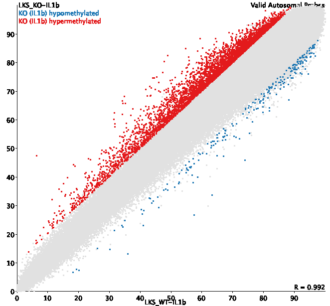

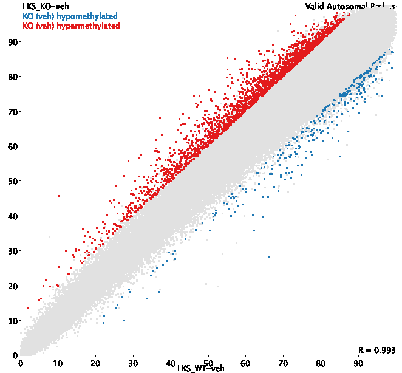

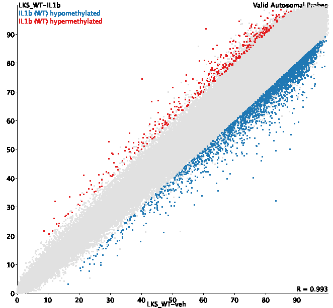

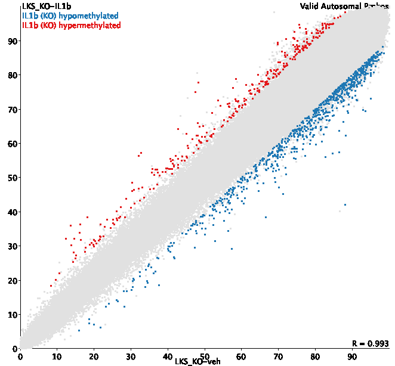

[figure not shown]